# Hospitalizations for psychiatric conditions among adolescents during the COVID-19 pandemic

# Setting up the R environment

### Installing packages and loading the library

```r
# Install packages
paket <- function(pak){
  new_pak <- pak[!(pak %in% rownames(installed.packages()))]
  if (length(new_pak))
    install.packages(new_pak, dependencies = TRUE,repos="https://cloud.r-project.org/")
  sapply(pak, library, character.only = TRUE)
}

listOfPackages <- c("tidyverse", "RColorBrewer", "knitr", "kableExtra", "tsModel", "gridExtra", "dplyr")
paket(listOfPackages)
```

### Plots aesthetics information

```r
# options(repr.plot.width = 18, repr.plot.height = 9)
theme_plots <- theme_bw() +
  theme(strip.text = element_text(size = 5),
        axis.text.x = element_text(size = 8),
        axis.text.y = element_text(size = 6),
        axis.title.x = element_text(size = 8),
        axis.title.y = element_text(size = 8),
        title = element_text(size = 10),
        plot.subtitle = element_text(size = 9, face = "italic"))
theme_set(theme_plots)

# Colorblind palette
cbPalette <- c("#999999", "#E69F00", "#56B4E9", "#009E73", "#F0E442", "#0072B2", "#D55E00", "#CC79A7")
```

# Data retrieval

## Inclusion criteria

The inclusion criteria for this study is:

- Patients inclusion criteria:
  - Age between 11-17 at the date of visit
- Visits inclusion criteria:
  - Inpatients (at least one hospitalization > 1 day)
  - Start date: January 1st, 2019
  - End date: May 31st, 2021
  - Comprising at least one ICD-10 code during hospitalization

## Variables that need to be checked/modified by each site

Change the values of the following variables according to the specificities of your site:

1. “folder_4ce_files”: folder path where your phase 2.2 data files are located
2. “obfuscation”: determine the obfuscation threshold (FALSE if no obfuscation, or the numeric value of the obfuscation threshold if any)
3. “raceAvailable”: set as TRUE or FALSE depending on whether the variable is being collected at your site
4. “dateFormat”: specify the format of the date at your site (e.g., for “03-AUG-20”, the format would be “%d-%b-%y”, [see documentation](https://www.stat.berkeley.edu/~s133/dates.html))
5. “data_update_date”: date at which the data has been updated in the local datawarehouse. Used to estimate patient age at time of visit, since patients age in the 4CE demographic file is expected the age at data update.
6. “time_period”: Time unit for the different graphs of the plots: months (default), weeks, days

```r
folder_4ce_files <- "../4ce_ped_psych/data"
obfuscation =  FALSE
#obfuscation = 3
raceAvailable = TRUE
#raceAvailable = FALSE
dateFormat <- "%d-%m-%y" #"%d-%b-%y"
min_hosp_days <- 2
data_update_date <- "2021-06-05"
time_period <-"months" #possible values: days, weeks, months
```

```r
# cut-off dates used in the analysis, these should not be changed
history_start_date <- as.Date("2019-01-01")
history_end_date <- as.Date("2021-05-31")
pandemic_start_date <- as.Date("2020-03-15")
start_date_plots <- as.Date("2019-01-15")
end_date_plots <- as.Date("2021-05-01")
```

## Data loading

We will use as input the 2.2 data files. Specifically:

- LocalPatientSummary
- LocalPatientObservation
- LocalPatientClinicalcourse

For sites recording the race, we will also use an additional file:

- LocalPatientRace

### Reading 4CE phase 2.2 files

### Read in Lurie files

```r
#non_psych_inpt_counts <- read.csv(paste0(folder_4ce_files, "/non_psych_inpt_counts.csv"))
non_psych_inpt_counts <- read.csv(paste0(folder_4ce_files, "/non_psych_admit_inpt_11_17.csv"))
admit_all_codes <- read.csv(paste0(folder_4ce_files, "/psych_admit_inpt_primary_all_icds.csv"))
admit_demog <- read.csv(paste0(folder_4ce_files, "/psych_admit_demog.csv"))
#admit_inpt_primary <- read.csv(paste0(folder_4ce_files, "/psych_admit_inpt_primary.csv"))
```

### Read the ICD10 codes file

The file containing the ICD10 psychiatric related codes is located in the `public-data` folder of the GitHub repository.

```r
icdCodes <- read.csv("public-data/pediatric_psychiatric_ICD10_codesV2.csv", header = TRUE, colClasses = "character") %>%
   filter( flag %in% c("originalCodes", "FrenchSpecificCodes")) %>%
   dplyr::select( disorder_group, ICD10_Code, description )
```

## Data-management

**Meghan Note: (Skip-to Lurie Data Formatting section)**

### Filtering on “inpatient” status

### Calculating duration of individual hospitalizations

Adding columns with hospitalization number and hospitalization length to the clinical raw file

# Lurie Data Formatting

**Clean up Lurie encounters**

As noted by Nelson: “some patients will have two encounters back-to-back. These should be considered the SAME encounter. The reason for having two encounters recorded is because medical admissions and psych admissions are considered separate admissions in our hospital. A simple way to deal with this redundancy is to check encounters for the same patient that start on the same day as the end of the prior encounter and merge those two into one encounter.”

**First we will combine all of the psych + non-psych data pulls**

```r
admit_demog <- rbind(admit_demog, non_psych_inpt_counts)
```

```r
## format dates
admit_demog$i_hsp_adm_dttm <- strptime(admit_demog$hsp_adm_dttm, format="%m/%d/%Y %H:%M") %>% as.POSIXct()
admit_demog$i_hsp_dsch_dttm <- strptime(admit_demog$hsp_dsch_dttm, format="%m/%d/%Y %H:%M") %>% as.POSIXct()

# unique encounter numbers should equal the row number (TRUE)
nrow(unique(data.frame(admit_demog$encounter_id))) == nrow(admit_demog)
```

```
## [1] TRUE
```

```r
encounters <- admit_demog %>%
  mutate(gender = if_else(gender == "Male", "male", "female")) %>%
  group_by(patient_id) %>%
  arrange(patient_id, i_hsp_adm_dttm) %>%
  filter(i_hsp_adm_dttm >= history_start_date & i_hsp_adm_dttm <= history_end_date) %>%
  mutate(encounter_group = seq_along(encounter_id),
         day_lag = round(difftime(i_hsp_adm_dttm, lag(i_hsp_dsch_dttm), unit = "hours")), 2) %>%
  data.frame() %>%
  # adding 100 to temporarily handle the NAs
  mutate(day_lag = ifelse(is.na(day_lag), 100, day_lag),
  # here we want to ensure that if subsequent encounters occurred within a day (24 hours), that we impute the initial encounter_group as per Nelson's suggestion
         i_encounter_group = ifelse(day_lag <= 24, lag(encounter_group), encounter_group)) %>%
  # in some cases there are more than two back-to-back encounters
  # to filter for these, first we will group by the patient_id and the new encounter group
  group_by(patient_id, i_encounter_group) %>%
  # next, we will calculate the latest admission date of this encounter
  mutate(max_date = max(i_hsp_adm_dttm)) %>%
  ungroup() %>%
  # next, we group just by Patient, and we identify the latest max_date
  # we then calculate the current time from the lag(max_date) and we will identify those within 24 hours as another encounter that should be grouped
  group_by(patient_id) %>%
  mutate(lag_date = lag(max_date),
         time_diff = as.numeric(difftime(i_hsp_adm_dttm, lag_date, unit = "hours"))) %>%
  # adding 100 to temporarily handle the NAs
  mutate(time_diff = ifelse(is.na(time_diff), 100, time_diff),
    i_encounter_group = ifelse(time_diff <= 24, lag(i_encounter_group), i_encounter_group),
  # recalculate the encounter sequence
  encounter_num = dense_rank(i_encounter_group))
```

Check to see if we should have combined any additional encounters

```r
test = encounters %>%
       group_by(patient_id, encounter_num) %>%
       mutate(max_date = max(i_hsp_adm_dttm)) %>%
  ungroup() %>%
  group_by(patient_id) %>%
  mutate(lag_date = lag(max_date),
         time_diff = as.numeric(difftime(i_hsp_adm_dttm, lag_date, unit = "hours")),
         check = if_else(time_diff <= 24 & encounter_num != lag(encounter_num), 1, 0))

#\View(test %>% filter(check == 1))
```

**Add number of hospitalizations and LOS of stay for each patient**

```r
clinical_raw <- encounters %>%
  group_by(patient_id) %>%
  mutate(n_hospitalisation = n_distinct(as.character(encounter_num))) %>%
  group_by(patient_id, encounter_num) %>%
  # calculate the hospitalization length, while taking care to select the max(i_hsp_dsch_dttm) in the case that we have more than 1 row per the same encounter
  mutate(len_hospitalisation = round(as.numeric(difftime(max(i_hsp_dsch_dttm), min(i_hsp_adm_dttm), unit = "days"))),
         # replace last discharge with the true discharge datetime
         i_hsp_dsch_dttm = max(i_hsp_dsch_dttm),
         # replace age_years with earliest age on admission
         age_years = min(age_years)) %>%
  rename("date" = i_hsp_adm_dttm,
         "patient_num" = patient_id) %>%
  group_by(patient_num, encounter_num) %>%
  slice(1L) %>%
  ungroup() %>%
  select(patient_num, date, i_hsp_dsch_dttm, race, ethnicity, gender, age_years, encounter_num, n_hospitalisation, len_hospitalisation) %>%
  distinct()
```

### Counting ICD10 mental health codes in the obs_raw table

```r
### check that the ICD codes follow the regular expression [A-Z][0-9][0-9AB]\.?[0-9A-TV-Z]{0,4}
codesToReview <- admit_all_codes %>% dplyr::filter(diagnosis_code == "DIAG-ICD10",
                                           ! grepl( "[A-Z][0-9][0-9AB]\\.?[0-9A-TV-Z]{0,4}", diagnosis_code))
print(codesToReview)
```

```
## [1] encounter_id          patient_id            diagnosis_code
## [4] diagnosis_code_source diagnosis_name        diagnosis_dttm
## [7] IsPrimary
## <0 rows> (or 0-length row.names)
```

```r
### Calculate how many of the mental codes are in the dataset
mentalHealthCodes <- unique( admit_all_codes %>%
  dplyr::filter( #concept_type == "DIAG-ICD10",
                 diagnosis_code %in% icdCodes$ICD10_Code ) %>%
  dplyr::mutate( diagnosis_code = as.character( diagnosis_code ),
                 concept_length = nchar( diagnosis_code ),
                 concept_check = ifelse( diagnosis_code == 4 | concept_length > 8, "Check", "OK")) %>%
  dplyr::select( diagnosis_code, concept_length, concept_check) )

summary(as.factor( mentalHealthCodes$concept_check ) )
```

```
##  OK
## 280
```

```r
print( paste0("There are ", length(mentalHealthCodes$diagnosis_code), " ICD10 mental codes out of the total ",length(unique(icdCodes$ICD10_Code)), " in the dataset"))
```

```
## [1] "There are 280 ICD10 mental codes out of the total 1699 in the dataset"
```

### Calculating age at hospitalization time

### Applying inclusion criteria to filter and format the data

We are selecting hospitalizations based on the following criteria:

- Associated with at least 1 ICD code
- With a duration of hospitalization spanning over at least two consecutive days
- Starting on or after 2019/01/01

### Further filtering Lurie data

```r
clinical_raw$date <- strptime(clinical_raw$date, format="%Y-%m-%d") %>% as.POSIXct()

# create list of calendar_dates
date_ids <- seq(as.Date("2019-01-01"), as.Date(history_end_date),
                by= "day") %>%
  data.frame() %>%
  rename('calendar_date' = '.')

date_ids <- date_ids %>%
  dplyr::mutate( date = as.Date( calendar_date, format = dateFormat ),
                 weeks = as.Date(cut( date, breaks = "week")),
                 month = as.Date(cut( date, breaks = "month")),
                 year = format( date, "%Y"),
                 period = ifelse( date < pandemic_start_date,
                                  "before_pandemic","during_pandemic"))

clinical_filtered <- clinical_raw %>%
  filter(len_hospitalisation >= min_hosp_days) %>%
  left_join(., date_ids, by = "date") %>%
   dplyr::mutate( date = as.Date( calendar_date, format = dateFormat ),
                  weeks = as.Date(cut( date, breaks = "week")),
                  month = as.Date(cut( date, breaks = "month")),
                  year = format( date, "%Y"),
                  period = ifelse( date < pandemic_start_date,
                                   "before_pandemic","during_pandemic"))


# check breaks example from BCH
example_bch <- read.delim2("example.txt", header = TRUE, sep = "")
example_lurie <- date_ids %>% distinct(calendar_date, weeks, month, year, period)

example_bch$calendar_date <- as.Date(example_bch$calendar_date)
example_bch$weeks <- as.Date(example_bch$weeks)
example_bch$month <- as.Date(example_bch$month)
example_bch$year <- as.character(example_bch$year)
example_bch <- example_bch %>% filter(!calendar_date >= "2021-06-01")

diff <- example_bch %>% anti_join(example_lurie)
nrow(diff)
```

```
## [1] 0
```

```r
diff <- example_lurie %>% anti_join(example_bch)
nrow(diff)
```

```
## [1] 0
```

```r
identical(example_bch, example_lurie)
```

```
## [1] TRUE
```

```r
all.equal(example_bch, example_lurie)
```

```
## [1] TRUE
```

```r
if( time_period == "weeks"){
  clinical_filtered$time_p <- clinical_filtered$weeks
}else if(time_period == "days"){
  clinical_filtered$time_p <- clinical_filtered$date
}else if(time_period == "months"){
  clinical_filtered$time_p <- clinical_filtered$month
}
```

**Create Lurie’s Input_data table**

```r
nrow(unique(data.frame(clinical_filtered$patient_num)))
```

```
## [1] 6350
```

```r
input_data <- clinical_filtered %>%
  mutate(age_years = floor(age_years)) %>%
  filter(date >= history_start_date & date <= history_end_date,
         age_years > 10 & age_years < 18) %>%
  group_by(patient_num, encounter_num) %>%
  arrange(date) %>%
  slice(1L) %>%
  ungroup() %>%
  select(patient_num, encounter_num, race, ethnicity, gender, age_years, date, i_hsp_dsch_dttm, weeks, month, year, period, time_p, n_hospitalisation, len_hospitalisation) %>%
  rename("sex" = gender,
         "age" = age_years)

nrow(unique(data.frame(input_data$patient_num)))
```

```
## [1] 4942
```

### Filtering on age 11-17

### Add the psychiatric/mental health ICD code description and filter

```r
# Getting site name, will be used later in the analysis
#site <- unique(as.character(demo_raw$siteid))
site <- "Lurie"

icdCategory <- read.delim("public-data/icd10Codes.txt",
                          header = FALSE,
                          colClasses = "character")
colnames(icdCategory) <- c("icd_code_letter", "icd_description_category")

# all_codes_desc <- all_codes_ado %>%
#     left_join( icdCodes, by=c("concept_code" = "ICD10_Code") ) %>%
#   mutate(icd_code_category = ifelse(concept_code %in% icdCodes$ICD10_Code,
#                                "psy",
#                                "others")) %>%
#   dplyr::select( patient_num, sex, age_time_diagnosis, concept_type, concept_code, calendar_date,
#                  in_hospital, n_hospitalisation, len_hospitalisation, date, weeks, month, year,
#                  period, time_p, disorder_group, description, icd_code_category )

# begin processing the ICD codes for the patients
all_codes_desc <- admit_all_codes %>%
   rename("patient_num" = patient_id,
          "concept_code" = diagnosis_code) %>%
  left_join(., icdCodes, by = c("concept_code" = "ICD10_Code")) %>%
  mutate(icd_code_category = ifelse(concept_code %in% icdCodes$ICD10_Code,
                               "psy",
                               "others"))

nrow(unique(data.frame(input_data$patient_num)))
```

```
## [1] 4942
```

```r
# Join mental health codes to the patient_number
input_data <- input_data %>%
  left_join(., all_codes_desc, by = "patient_num") %>%
  mutate(i_diagnosis_dttm = strptime(diagnosis_dttm, format="%m/%d/%Y") %>% as.POSIXct(),
         date = strptime(date, format="%Y-%m-%d") %>% as.POSIXct(),
         i_hsp_dsch_dttm = strptime(i_hsp_dsch_dttm, format="%Y-%m-%d") %>% as.POSIXct()) %>%
  dplyr::filter( #diagnosis_code_source == "ICD-10-CM",
                 #in_hospital == 1,
                 age > 10 & age < 18,
                 date >= history_start_date & date <= history_end_date)

# we will temporarily split the data frame between our psych patients with ICD codes and our non-pysch without, due to the filtering function automatically dropping rows with missing ICD codes
# of note: these are just some patients who have an ICD code - could be some non-psych codes as the original query including some icd codes for poisoning that ended up being excluded
keep_psych <- input_data %>%
  filter(i_diagnosis_dttm >= date & i_diagnosis_dttm <= i_hsp_dsch_dttm) %>%
  dplyr::select( patient_num, encounter_num, sex, age, race, concept_code, n_hospitalisation, len_hospitalisation,
                 date, weeks, month, year, period, time_p, disorder_group, description, icd_code_category)

keep_non_psych = input_data %>%
  filter(is.na(i_diagnosis_dttm)) %>%
  dplyr::select( patient_num, encounter_num, sex, age, race, concept_code, n_hospitalisation, len_hospitalisation,
                 date, weeks, month, year, period, time_p, disorder_group, description, icd_code_category)

input_data <- rbind(keep_psych, keep_non_psych)

nrow(unique(data.frame(input_data$patient_num)))
```

```
## [1] 4925
```

```r
all_codes_desc <- input_data %>%
  mutate( icd_code_letter = ifelse(substr(concept_code, 1, 1) %in% c("D", "H"), substr(concept_code, 1, 2), substr(concept_code, 1, 1) ))

all_codes_desc <- left_join( all_codes_desc, icdCategory) %>%
  mutate( icd_description_category = replace_na( ifelse( concept_code %in% icdCodes$ICD10_Code, "Psy", icd_description_category), "Others"),
          icd_code_category = ifelse(is.na(icd_code_category), "others", icd_code_category))


all_codes_psy <- all_codes_desc %>%
  filter(concept_code %in% icdCodes$ICD10_Code)

nrow(unique(data.frame(all_codes_psy$patient_num)))
```

```
## [1] 933
```

```r
#all_codes_desc$i_date <- strptime(all_codes_desc$date, format="%Y-%m-%d") %>% as.POSIXct()

# if( raceAvailable == TRUE ){
#   all_codes_psy <- all_codes_psy %>%
#     left_join( race_raw, by = c("patient_num") )
# }
```

QC Checks for Pysch patients

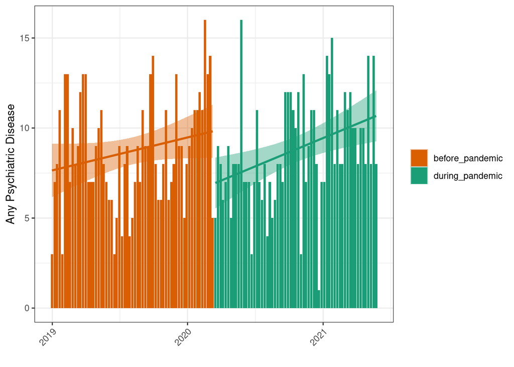

```r
p1 <- ggplot(all_codes_desc %>%
               filter(icd_code_category == "psy") %>%
               group_by(weeks, period) %>%
               arrange(weeks) %>%
               mutate(psych_any_count = n_distinct(patient_num, encounter_num),
                      weeks = as.Date(weeks)) %>%
               distinct(weeks, psych_any_count, period),
       aes(x = weeks, y = psych_any_count, fill = period)) +
  geom_bar(stat="identity", binwidth=1) +
  geom_smooth(method = "lm", se = TRUE, aes(color = period)) +
  scale_color_brewer(palette="Dark2", direction = -1) +
  scale_fill_brewer(palette = "Dark2", direction = -1) +
  ylab("Any Psychiatric Disease") +
  xlab("") +
  #scale_x_date(date_labels = "%b-%y", date_breaks = "1 month", expand = c(0,0)) +
  theme_bw() +
  theme(legend.title = element_blank(),
        axis.text.x = element_text(angle = 45, hjust = 1))
p1
```

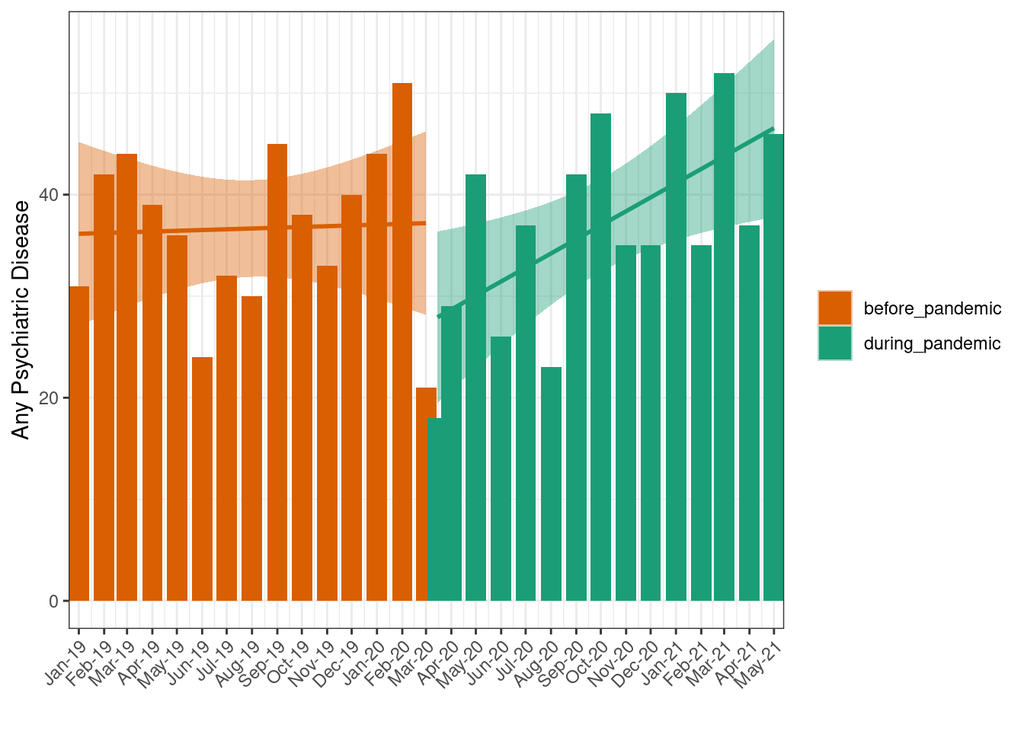

```r
# add an extra day to distingush the before and during which occur in same month

p1 <- ggplot(all_codes_desc %>%
               filter(icd_code_category == "psy") %>%
               group_by(month) %>%
               arrange(month) %>%
               mutate(month = as.character(month),
                 month = ifelse(month == "2020-03-01" & period == "during_pandemic", "2020-03-15", month)) %>%
               group_by(month, period) %>%
               mutate(psych_any_count = n_distinct(patient_num, encounter_num),
                      month = as.Date(month)) %>%
               ungroup() %>%
               distinct(month, psych_any_count, period),
       aes(x = month, y = psych_any_count, fill = period)) +
  geom_bar(stat="identity", width = 25) +
  geom_smooth(method = "lm", se = TRUE, aes(color = period)) +
  scale_color_brewer(palette="Dark2", direction = -1) +
  scale_fill_brewer(palette = "Dark2", direction = -1) +
  ylab("Any Psychiatric Disease") +
  xlab("") +
  scale_x_date(date_labels = "%b-%y", date_breaks = "1 month", expand = c(0,0)) +
  theme_bw() +
  theme(legend.title = element_blank(),
        axis.text.x = element_text(angle = 45, hjust = 1))

p1
```

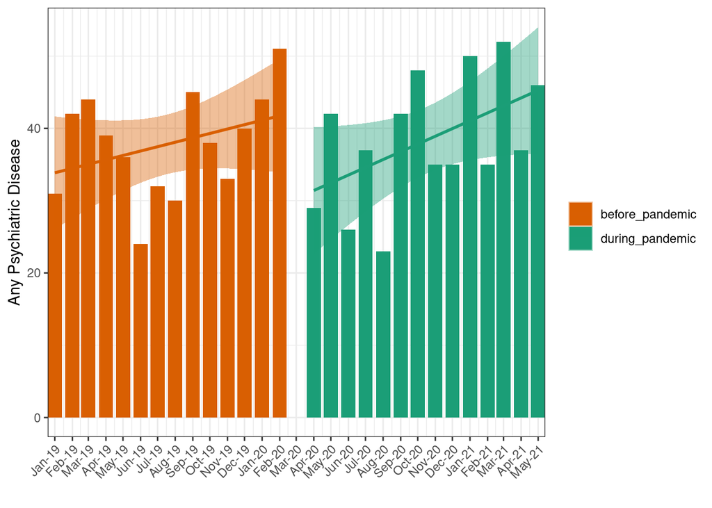

```r
# p1 <- ggplot(all_codes_desc %>%
#                filter(icd_code_category == "psy") %>%
#                group_by(month) %>%
#                arrange(month) %>%
#                mutate(month = as.character(month),
#                  period = ifelse(month == "2020-03-01", "March", period)) %>%
#                group_by(month, period) %>%
#                mutate(psych_any_count = n_distinct(patient_num, encounter_num),
#                       month = as.Date(month)) %>%
#                ungroup() %>%
#                distinct(month, psych_any_count, period),
#        aes(x = month, y = psych_any_count, fill = period)) +
#   geom_bar(stat="identity", width = 25) +
#   geom_smooth(method = "lm", se = TRUE, aes(color = period)) +
#   scale_color_brewer(palette="Dark2", direction = -1) +
#   scale_fill_brewer(palette = "Dark2", direction = -1) +
#   ylab("Any Psychiatric Disease") +
#   xlab("") +
#   scale_x_date(date_labels = "%b-%y", date_breaks = "1 month", expand = c(0,0)) +
#   theme_bw() +
#   theme(legend.title = element_blank(),
#         axis.text.x = element_text(angle = 45, hjust = 1))
#
# p1

# remove march
p1 <- ggplot(all_codes_desc %>%
               filter(icd_code_category == "psy") %>%
               group_by(month) %>%
               arrange(month) %>%
               mutate(month = as.character(month)) %>%
               filter(!month == "2020-03-01") %>%
                 #month = ifelse(month == "2020-03-01" & period == "during_pandemic", "2020-03-15", month)) %>%
               group_by(month, period) %>%
               mutate(psych_any_count = n_distinct(patient_num, encounter_num),
                      month = as.Date(month)) %>%
               ungroup() %>%
               distinct(month, psych_any_count, period),
       aes(x = month, y = psych_any_count, fill = period)) +
  geom_bar(stat="identity", width = 25) +
  geom_smooth(method = "lm", se = TRUE, aes(color = period)) +
  scale_color_brewer(palette="Dark2", direction = -1) +
  scale_fill_brewer(palette = "Dark2", direction = -1) +
  ylab("Any Psychiatric Disease") +
  xlab("") +
  scale_x_date(date_labels = "%b-%y", date_breaks = "1 month", expand = c(0,0)) +
  theme_bw() +
  theme(legend.title = element_blank(),
        axis.text.x = element_text(angle = 45, hjust = 1))

p1
```

### Psych vs Non-psych

this plot is different than Alba’s later on. I wonder if the same patient could be present in same month/period with vs with psych condition

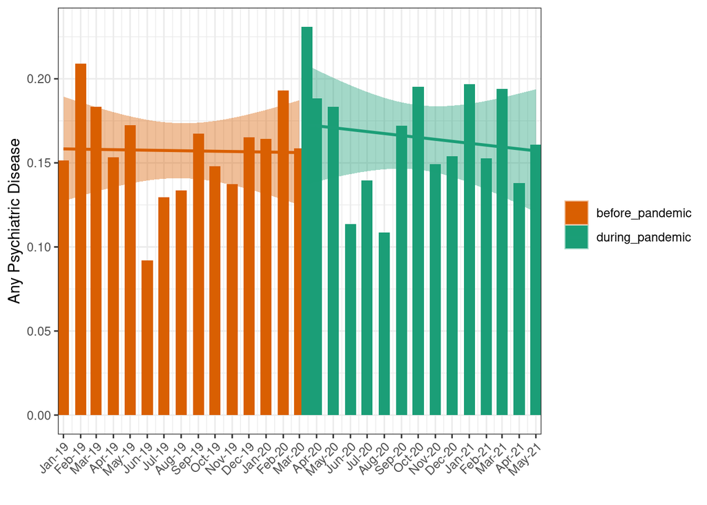

```r
p1 <- ggplot(all_codes_desc %>%
               #filter(icd_code_category == "psy") %>%
               # first, for each month, we will modify the data, so that if a patient has a psych AND non-psych admission in the first month, we will only count their psych admission
               group_by(month) %>%
               mutate(check = if_else(icd_code_category == "psy", 1, 0)) %>%
               group_by(patient_num, month) %>%
               filter(check == max(check)) %>%
               slice(1) %>%
               group_by(month, period, icd_code_category) %>%
               arrange(month) %>%
               mutate(psych_any_count = n_distinct(patient_num, encounter_num),
                      month = as.character(month),
                      month = ifelse(month == "2020-03-01" & period == "during_pandemic", "2020-03-15", month),
                      month = as.Date(month)) %>%
               distinct(month, icd_code_category, psych_any_count, period) %>%
               pivot_wider(names_from = icd_code_category, values_from = psych_any_count) %>%
               mutate(sum = psy + others,
                      perc_psyc = psy/sum),
       aes(x = month, y = perc_psyc, fill = period)) +
  geom_bar(stat="identity", width = 20) +
  geom_smooth(method = "lm", se = TRUE, aes(color = period)) +
  scale_color_brewer(palette="Dark2", direction = -1) +
  scale_fill_brewer(palette = "Dark2", direction = -1) +
  ylab("Any Psychiatric Disease") +
  xlab("") +
  scale_x_date(date_labels = "%b-%y", date_breaks = "1 month", expand = c(0,0)) +
  #facet_wrap(~icd_code_category) +
  theme_bw() +
  theme(legend.title = element_blank(),
        axis.text.x = element_text(angle = 45, hjust = 1))

p1
```

```r
test <- all_codes_desc %>%
               #filter(icd_code_category == "psy") %>%
               # first, for each month, we will modify the data, so that if a patient has a psych AND non-psych admission in the first month, we will only count their psych admission
               group_by(month) %>%
               mutate(check = if_else(icd_code_category == "psy", 1, 0)) %>%
               group_by(patient_num, month) %>%
               filter(check == max(check)) %>%
               slice(1) %>%
               group_by(month, period, icd_code_category) %>%
               arrange(month) %>%
               mutate(psych_any_count = n_distinct(patient_num, encounter_num),
                      month = as.character(month),
                      month = ifelse(month == "2020-03-01" & period == "during_pandemic", "2020-03-15", month),
                      month = as.Date(month)) %>%
               distinct(month, icd_code_category, psych_any_count, period) %>%
               pivot_wider(names_from = icd_code_category, values_from = psych_any_count) %>%
               mutate(sum = psy + others,
                      perc_psyc = psy/sum)


before <- test %>% filter(period == "before_pandemic")
during <- test %>% filter(period == "during_pandemic")

summary(before$perc_psyc)
```

```
##    Min. 1st Qu.  Median    Mean 3rd Qu.    Max.
## 0.09195 0.14268 0.15873 0.15723 0.16986 0.20896
```

```r
summary(during$perc_psyc)
```

```
##    Min. 1st Qu.  Median    Mean 3rd Qu.    Max.
##  0.1085  0.1444  0.1608  0.1651  0.1911  0.2308
```

```r
# don't divide by month

test <- all_codes_desc %>%
               #filter(icd_code_category == "psy") %>%
               # first, for each month, we will modify the data, so that if a patient has a psych AND non-psych admission in the first month, we will only count their psych admission
               group_by(month) %>%
               mutate(check = if_else(icd_code_category == "psy", 1, 0)) %>%
               group_by(patient_num, month) %>%
               filter(check == max(check)) %>%
               slice(1) %>%
               group_by(period, icd_code_category) %>%
               arrange(month) %>%
               mutate(psych_any_count = n_distinct(patient_num, encounter_num),
                      month = as.character(month),
                      month = ifelse(month == "2020-03-01" & period == "during_pandemic", "2020-03-15", month),
                      month = as.Date(month)) %>%
               distinct(icd_code_category, psych_any_count, period) %>%
               pivot_wider(names_from = icd_code_category, values_from = psych_any_count) %>%
               mutate(sum = psy + others,
                      perc_psyc = psy/sum)


before <- test %>% filter(period == "before_pandemic")
during <- test %>% filter(period == "during_pandemic")

summary(before$perc_psyc)
```

```
##    Min. 1st Qu.  Median    Mean 3rd Qu.    Max.
##  0.1565  0.1565  0.1565  0.1565  0.1565  0.1565
```

```r
summary(during$perc_psyc)
```

```
##    Min. 1st Qu.  Median    Mean 3rd Qu.    Max.
##  0.1621  0.1621  0.1621  0.1621  0.1621  0.1621
```

### Add the non-pysch patient encounters

Combine the psych and non-psych dataframes

#### QC step: do a summary of the mental health ICD codes present in each site

As output we will generate a table with: the number of observations per code, number of patients diagnosed with each code and the date range in which the code was used.

```r
#filter the whole dataset to only mental codes
mental_codes_qc <- all_codes_desc %>%
  filter( concept_code %in% mentalHealthCodes$diagnosis_code)

mental_codes_qc_output <- mental_codes_qc %>%
  group_by( concept_code ) %>%
  dplyr::summarise( distinct_patients = ifelse(length(unique(patient_num)) > obfuscation | isFALSE(obfuscation),
                               length(unique(patient_num)),
                               0.5),
                    distinct_observations = ifelse(length(patient_num) > obfuscation | isFALSE(obfuscation),
                               length(patient_num),
                               0.5),
                    min_date = min( date ),
                    max_date = max( date ))%>%
  arrange(desc(distinct_observations))
mental_codes_qc_output <- left_join( mental_codes_qc_output, icdCodes, by=c("concept_code"= "ICD10_Code"))
mental_codes_qc_output  <- mental_codes_qc_output[, c("disorder_group", "description", "concept_code", "distinct_patients",
                                                    "distinct_observations", "min_date", "max_date")]
mental_codes_qc_output[1:10, ]
```

```
## # A tibble: 10 x 7
##    disorder_group description concept_code distinct_patien… distinct_observ…
##    <chr>          <chr>       <chr>                   <int>            <int>
##  1 Suicide or Se… Suicidal i… R45.851                   755             2134
##  2 Depressive Di… Major depr… F32.9                     780             1945
##  3 Anxiety Disor… Anxiety di… F41.9                     646             1281
##  4 Anxiety Disor… Generalize… F41.1                     399             1043
##  5 Anxiety Disor… Social pho… F40.10                    158              314
##  6 Trauma and St… Post-traum… F43.10                    107              260
##  7 Suicide or Se… Suicide at… T14.91XA                  136              225
##  8 Suicide or Se… Poisoning … T39.1X2A                   80              204
##  9 Miscellaneous  Unspecifie… F39                       102              200
## 10 Substance-Rel… Cannabis u… F12.90                    135              191
## # … with 2 more variables: min_date <dttm>, max_date <dttm>
```

# Results

## Admission

First calculation: total number of patients, matching the inclusion criteria, admitted on one day (without filtering by any disease subtype). Summed up over one week, or one month depending on the time unit chosen. Not filtered on qge.

```r
admission_plot_count <- function(df,
                               x,
                               y,
                               title,
                               y_title,
                               size = NULL,
                               color = NULL){
  plot <- ggplot(df, aes_string(x = x, y = y, color = color, size = size))  +
    geom_point() +
    scale_x_date(date_breaks = "1 month", date_labels =  "%b %Y", limits = c(start_date_plots, end_date_plots), expand = expansion(mult = 0.01, add = 1)) +
    theme(axis.text.x=element_text(angle=60, hjust=1))+
    labs(x = "Calendar date",
         y = y_title,
       title = title)
  return(plot)
}
```

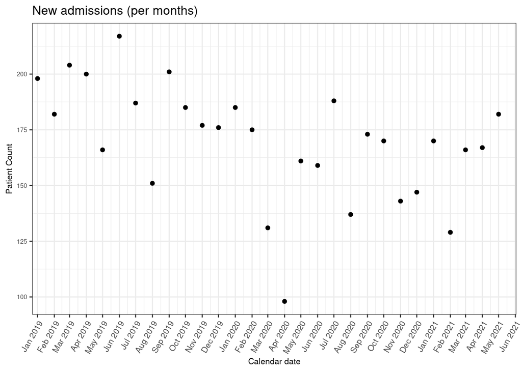

```r
new_hospitalizations <- all_codes_desc %>%
  group_by(patient_num, n_hospitalisation) %>%
  slice(which.min(time_p)) %>%
  #filter( in_hospital == 1 ) %>%
    group_by( time_p ) %>%
  summarise(count = ifelse(n_distinct(patient_num) > obfuscation | isFALSE(obfuscation),
                               n_distinct(patient_num),
                               0.5)) %>%
  ungroup()

start_date_plots <- as.Date("2019-01-01")
end_date_plots <- as.Date("2021-05-24")

nh <- admission_plot_count(df = new_hospitalizations,
                     x = "time_p",
                     y = "count",
                     title = paste0("New admissions (per ", time_period,")"),
                     y_title = "Patient Count")

nh
```

## New admissions age range 11-17

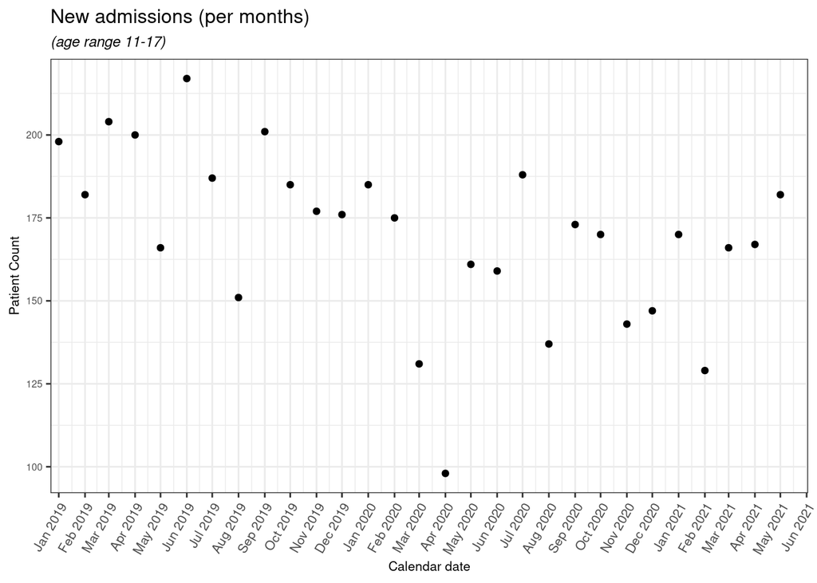

```r
new_hospitalizations_ado <- all_codes_desc %>%
  group_by(patient_num, n_hospitalisation) %>%
  slice(which.min(time_p)) %>%
  #filter( in_hospital == 1 ) %>%
    group_by( time_p ) %>%
  summarise(count = ifelse(n_distinct(patient_num) > obfuscation | isFALSE(obfuscation),
                               n_distinct(patient_num),
                               0.5)) %>%
  ungroup()

start_date_plots <- as.Date("2019-01-01")
end_date_plots <- as.Date("2021-05-24")

nh_ado <- admission_plot_count(df = new_hospitalizations_ado,
                     x = "time_p",
                     y = "count",
                     title = paste0("New admissions (per ", time_period, ")"),
                     y_title = "Patient Count")+
    labs( subtitle = "(age range 11-17)")

nh_ado
```

## Total hospitalize patients age range 11-17

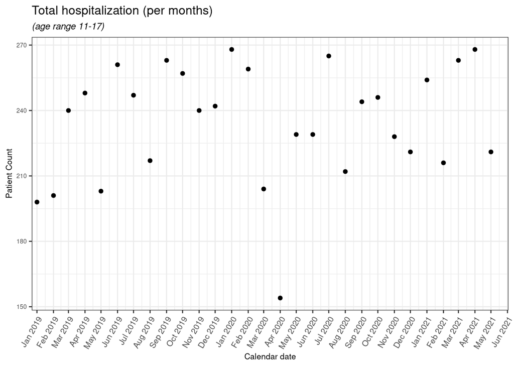

```r
unique_patients_hospitalized <- all_codes_desc %>%
  filter(date < end_date_plots &
         date >= start_date_plots ) %>%
    group_by( time_p ) %>%
  summarise(count = ifelse(n_distinct(patient_num) > obfuscation | isFALSE(obfuscation),
                               n_distinct(patient_num),
                               0.5))

th <- admission_plot_count(df = unique_patients_hospitalized,
                     x = "time_p",
                     y = "count",
                     title = paste0("Total hospitalization (per ", time_period, ")"),
                     y_title = "Patient Count") +
  labs( subtitle = "(age range 11-17)")
th
```

## Patient count filtered on psychiatric disorders

### New admissions

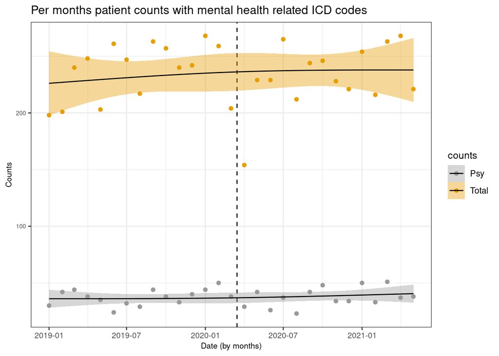

```r
count_icd_psy <- all_codes_psy %>%
  filter(date < end_date_plots &
         date >= start_date_plots ) %>%
    group_by( time_p ) %>%
  summarise(count_psy =  ifelse(n_distinct(patient_num) > obfuscation | isFALSE(obfuscation),
                               n_distinct(patient_num),
                               0.5)) %>%
  mutate( period = ifelse( time_p < pandemic_start_date,
                           "before_pandemic",
                           "during_pandemic")
  )

count_icd <- all_codes_desc %>%
  filter(date < end_date_plots &
         date >= start_date_plots ) %>%
    group_by( time_p ) %>%
  summarise(count_icd =  ifelse(n_distinct(patient_num) > obfuscation | isFALSE(obfuscation),
                               n_distinct(patient_num),
                               0.5)) %>%
  mutate( period = ifelse( time_p < pandemic_start_date,
                           "before_pandemic",
                           "during_pandemic")
  )

count_icd <- count_icd %>%
  left_join(count_icd_psy,
            by = c("time_p", "period")) %>%
  replace_na(list(count_psy = 0))

count_icd$percentage_psy <- 100*count_icd$count_psy / count_icd$count_icd


thpd_psyCount <- count_icd %>%
  pivot_longer(names_to = "counts", cols=c(count_psy, count_icd)) %>%
  mutate( counts = ifelse( counts == "count_psy", "Psy", "Total")) %>%
  ggplot(aes(x = time_p, y = value, fill = counts, color = counts)) +
  geom_point() +
  # geom_line() +
  geom_vline(xintercept = as.Date(pandemic_start_date),
             linetype = "dashed") +
  scale_fill_manual(values = cbPalette) +
  scale_color_manual(values = cbPalette) +
  labs(y = "Counts",
       x = paste0("Date (by ", time_period,")"),
       title = paste0("Per ", time_period , " patient counts with mental health related ICD codes")) +
  geom_smooth(method = "lm", formula = y ~ splines::ns(x, 2), se = TRUE, aes(colour=period), colour= "black", size = 0.5)


thpd_psyCount
```

### Ratio: patients with psychiatric condition / patients without psychiatric condition

```r
all_patients <- unique( all_codes_desc[, c("patient_num", "time_p")])
nrow(unique(data.frame(all_patients$patient_num)))
```

```
## [1] 4925
```

```r
patients_with_psy_conditions <- unique( all_codes_psy[, c("patient_num", "time_p")] )
nrow(unique(data.frame(patients_with_psy_conditions$patient_num)))
```

```
## [1] 933
```

```r
patients_without_psy_conditions <- setdiff(all_patients,patients_with_psy_conditions)
nrow(unique(data.frame(patients_without_psy_conditions$patient_num)))
```

```
## [1] 3992
```

```r
patients_without_psy_conditions_counts <- patients_without_psy_conditions %>%
  group_by( time_p ) %>%
  summarise(count_no_psy_patients =  ifelse(n_distinct(patient_num) > obfuscation | isFALSE(obfuscation),
                               n_distinct(patient_num),
                               0.5)) %>%
  mutate( period = ifelse( time_p < pandemic_start_date,
                           "before_pandemic",
                           "during_pandemic"))


patients_with_psy_conditions_counts <-  patients_with_psy_conditions %>%
  group_by( time_p ) %>%
  summarise(count_psy_patients =  ifelse(n_distinct(patient_num) > obfuscation | isFALSE(obfuscation),
                               n_distinct(patient_num),
                               0.5)) %>%
  mutate( period = ifelse( time_p < pandemic_start_date,
                           "before_pandemic",
                           "during_pandemic"))

  ratios_patients_with_without_psy <- patients_without_psy_conditions_counts %>%
  full_join( patients_with_psy_conditions_counts, by=c("time_p", "period")) %>%
  mutate( ratio = count_psy_patients/count_no_psy_patients,
          percentage = 100 * count_psy_patients/(count_no_psy_patients + count_psy_patients))
```

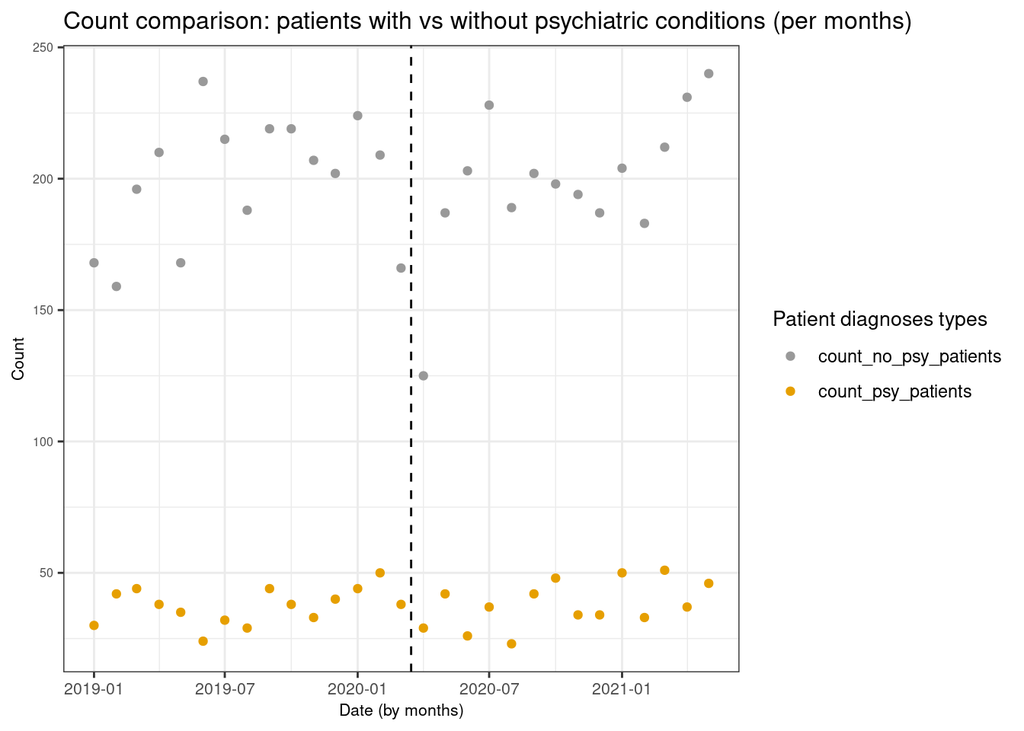

```r
ratios_patients_with_without_psy %>%
  pivot_longer(cols = c("count_no_psy_patients", "count_psy_patients"),
               values_to = "count",
               names_to = "count_type") %>%
  ggplot(aes(x = time_p, y = count, color = count_type)) +
  geom_point() +
  geom_vline(xintercept = as.Date(pandemic_start_date),
             linetype = "dashed") +
  scale_fill_manual(values = cbPalette) +
  scale_color_manual(values = cbPalette) +
  labs(y = "Count",
       x = paste0("Date (by ", time_period,")"),
       title = paste0("Count comparison: patients with vs without psychiatric conditions (per ", time_period,")")) +
  guides(color = guide_legend(title="Patient diagnoses types"))
```

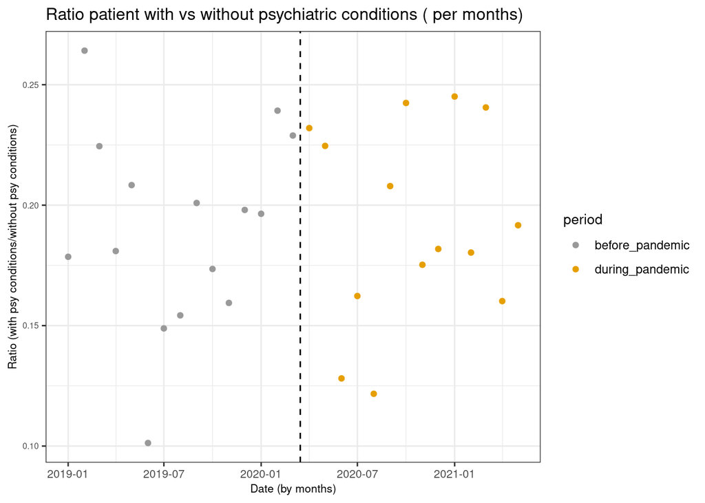

```r
ratio_psy_non_psy <- ratios_patients_with_without_psy %>%
  ggplot(aes(x = time_p, y = ratio, fill = period, color = period)) +
  geom_point() +
  geom_vline(xintercept = as.Date(pandemic_start_date),
             linetype = "dashed") +
  scale_fill_manual(values = cbPalette) +
  scale_color_manual(values = cbPalette) +
  labs(y = "Ratio (with psy conditions/without psy conditions)",
       x = paste0("Date (by ", time_period,")"),
       title = paste0("Ratio patient with vs without psychiatric conditions ( per ", time_period,")"))

ratio_psy_non_psy
```

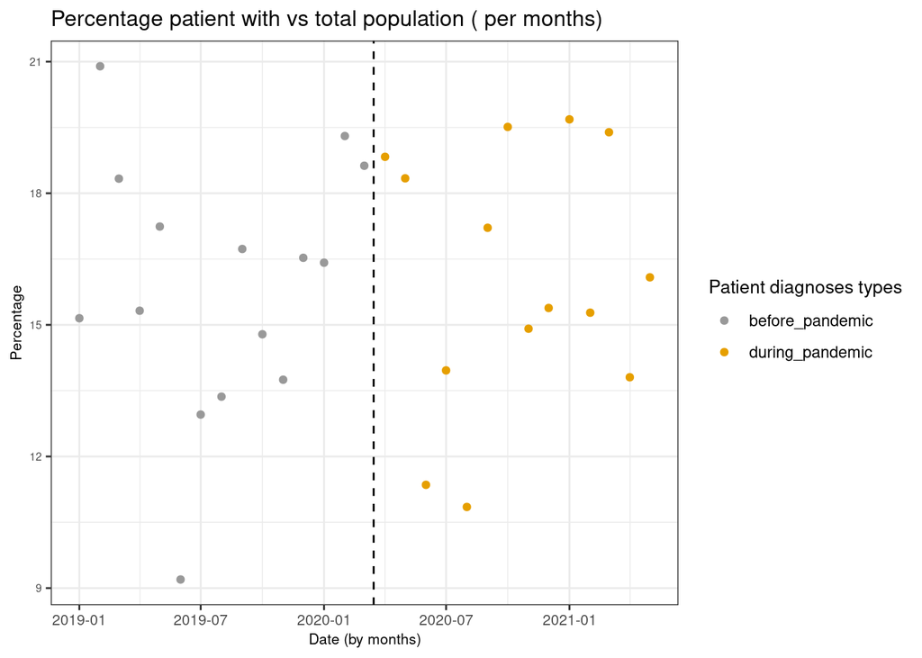

```r
ratios_patients_with_without_psy %>%
  ggplot(aes(x = time_p, y = percentage, color = period)) +
  geom_point() +
  geom_vline(xintercept = as.Date(pandemic_start_date),
             linetype = "dashed") +
  scale_fill_manual(values = cbPalette) +
  scale_color_manual(values = cbPalette) +
  labs(y = "Percentage",
       x = paste0("Date (by ", time_period,")"),
       title = paste0("Percentage patient with vs total population ( per ", time_period,")")) +
  guides(color = guide_legend(title="Patient diagnoses types"))
```

## Interrupted Time-Series Analyses

```r
# Model without seasonality
time_series_analysis_plotting <- function(model, df_count_psy, count_col, clearance_period = FALSE) {
  output_model <- broom::tidy(model)
  coeff_slope <- round(output_model[output_model$term == "periodduring_pandemic:time", "estimate"][[1]], 3)
  pvalue_slope <- round(output_model[output_model$term == "periodduring_pandemic:time", "p.value"][[1]], 3)
  annotation <- paste0("Lockdown slope: ", coeff_slope, " (pvalue: ", pvalue_slope, ")")
  pred_model <- predict(model, df_count_psy, type = "response", interval = "confidence") %>% as.data.frame()
  pred_model_b <- predict(model, mutate(df_count_psy, period = "before_pandemic"), type = "response", interval = "confidence") %>%
    as.data.frame()
  names(pred_model_b) <- paste0(names(pred_model_b), "_wo_intervention")
  pred_model <- bind_cols(df_count_psy, pred_model, pred_model_b)
  if (clearance_period) {
    pred_model$clearance_period <- ifelse(pred_model$time_p < as.Date(cut(start_clear_period, breaks = time_period)) ,
                                          "before_pandemic",
                                          ifelse(pred_model$time_p > as.Date(cut(end_clear_period, breaks = time_period)),
                                                 "during_pandemic",
                                                 "during_clearance")
    )
    pred_model$lwr <- ifelse(pred_model$clearance_period == "during_clearance", NA, pred_model$lwr)
    pred_model$upr <- ifelse(pred_model$clearance_period == "during_clearance", NA, pred_model$upr)
    pred_model$fit_wo_intervention <- ifelse(pred_model$time_p >= max(pred_model$time_p[pred_model$clearance_period == "before pandemic"]),
                                             pred_model$fit_wo_intervention,
                                             NA)
  } else {
    pred_model$clearance_period <- pred_model$period
  }
  plot <- ggplot(pred_model, aes_string(x = "time_p", y = count_col)) +
    geom_point(aes(colour = clearance_period)) +
    geom_line(aes(x = time_p, y = fit_wo_intervention, colour = "Expected mean w/o pandemic"), linetype = "dashed") +
    geom_line(aes(x = time_p, y = fit, colour = clearance_period)) +
    geom_ribbon(aes(ymin = lwr, ymax = upr, colour = clearance_period), alpha = 0.3, colour = NA) +
    scale_color_manual(name = "Time Series projection", values = c("before_pandemic" = "black",
                                                                   "Expected mean w/o pandemic" = "red",
                                                                   "during_pandemic" = "black",
                                                                   "during_clearance" = "white")) +
    annotate("text", x = as.Date("2019-10-01"), y = max(pred_model[[count_col]]) + 5, label = annotation) +
    theme(legend.position = "bottom")

  if (clearance_period) {
    plot +
      geom_vline(xintercept = as.Date(max(pred_model$time_p[pred_model$clearance_period == "before_pandemic"])), linetype = "dashed") +
      geom_vline(xintercept = as.Date(min(pred_model$time_p[pred_model$clearance_period == "during_pandemic"])), linetype = "dashed")
  } else {
    plot + geom_vline(xintercept = as.Date(pandemic_start_date), linetype = "dashed")
  }
}
```

```r
# Time series analysis of percentage of psy codes per encounter, linear (without seasonality)
patient_count_psy_period_psy <- ratios_patients_with_without_psy %>%
  filter(time_p > as.Date(cut( start_date_plots, breaks = time_period)) &
           time_p < as.Date(cut( end_date_plots, breaks = time_period))) %>%
  mutate(time = seq_along(time_p),
         month_year = format(time_p, "%m")
  )

start_clear_period <- as.Date("2020-03-15")
end_clear_period <- as.Date("2020-05-15")
patient_count_psy_period_psy_clear <- patient_count_psy_period_psy %>%
  mutate( count_no_psy_patients = ifelse(time_p < as.Date(cut( start_clear_period, breaks = time_period)) |
                               time_p > as.Date(cut( end_clear_period, breaks = time_period)),
                             count_no_psy_patients,
                             NA),
          count_no_psy_patients = ifelse(time_p < as.Date(cut( start_clear_period, breaks = time_period)) |
                               time_p > as.Date(cut( end_clear_period, breaks = time_period)),
                             count_no_psy_patients,
                             NA),
          ratio = ifelse(time_p < as.Date(cut( start_clear_period, breaks = time_period)) |
                           time_p > as.Date(cut( end_clear_period, breaks = time_period)),
                         ratio,
                         NA),
          percentage = ifelse(time_p < as.Date(cut( start_clear_period, breaks = time_period)) |
                           time_p > as.Date(cut( end_clear_period, breaks = time_period)),
                         percentage,
                         NA)
  )
```

```r
ts_linear_count <- lm(count_psy_patients ~ period * time, patient_count_psy_period_psy)
ts_linear_count_clear <- lm(count_psy_patients ~ period * time, patient_count_psy_period_psy_clear)
ts_seasonal_count <- lm(count_psy_patients ~ period*time + harmonic(month_year, 1, 12), patient_count_psy_period_psy)
ts_seasonal_count_clear <- lm(count_psy_patients ~ period*time + harmonic(month_year, 1, 12), patient_count_psy_period_psy_clear)
```

```r
ts_linear_percent <- lm(percentage ~ period * time, patient_count_psy_period_psy)
ts_linear_percent_clear <- lm(percentage ~ period * time, patient_count_psy_period_psy_clear)
ts_seasonal_percent <- lm(percentage ~ period*time + harmonic(month_year, 1, 12), patient_count_psy_period_psy)
ts_seasonal_percent_clear <- lm(percentage ~ period*time + harmonic(month_year, 1, 12), patient_count_psy_period_psy_clear)
```

### ITS: patient counts, no clearance period, no seasonality effect

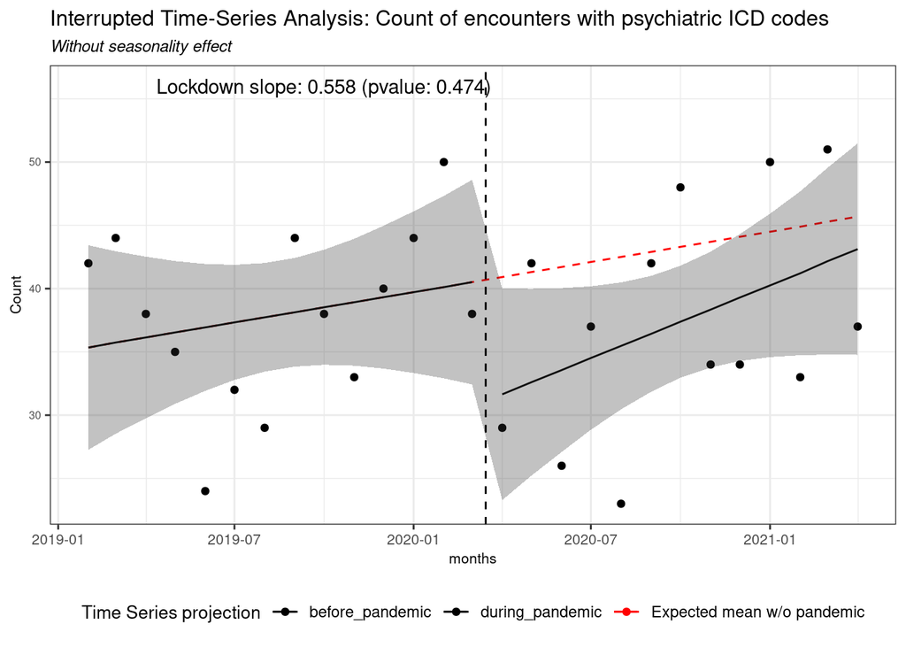

```r
time_series_analysis_plotting(ts_linear_count,
                              patient_count_psy_period_psy,
                              "count_psy_patients",
                              clearance_period = FALSE) +
  labs(title = "Interrupted Time-Series Analysis: Count of encounters with psychiatric ICD codes",
       subtitle = "Without seasonality effect",
       x = time_period,
       y = "Count")
```

### ITS: patient counts, clearance period, no seasonality effect

[figure not shown]

```r
time_series_analysis_plotting(ts_linear_count_clear,
                              patient_count_psy_period_psy,
                              "count_psy_patients",
                              clearance_period = TRUE) +
  labs(title = "Interrupted Time-Series Analysis: Percentage of encounters with psychiatric ICD codes",
       subtitle = "Without seasonality effect",
       x = time_period,
       y = "Count")
```

### ITS: patient counts, no clearance period, with seasonality effect

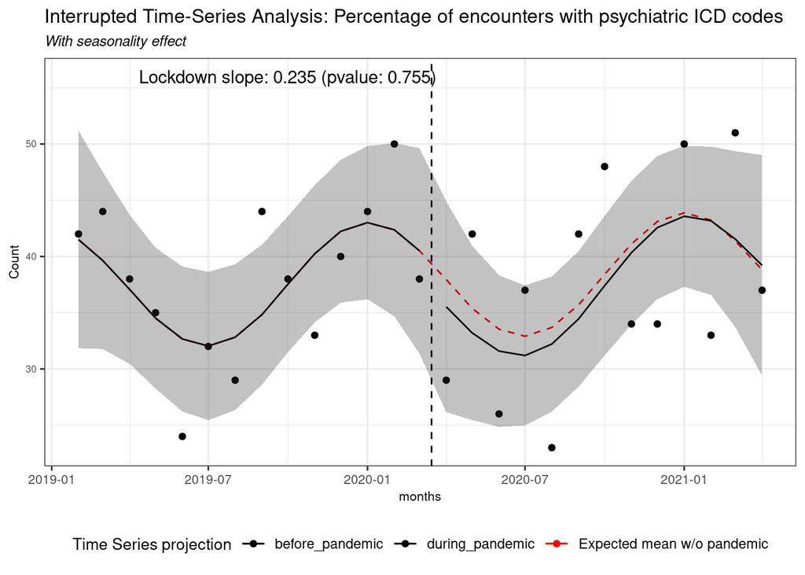

```r
time_series_analysis_plotting(ts_seasonal_count,
                              patient_count_psy_period_psy,
                              "count_psy_patients",
                              clearance_period = FALSE) +
  labs(title = "Interrupted Time-Series Analysis: Percentage of encounters with psychiatric ICD codes",
       subtitle = "With seasonality effect",
       x = time_period,
       y = "Count")
```

### ITS: patient counts, with clearance period, with seasonality effect

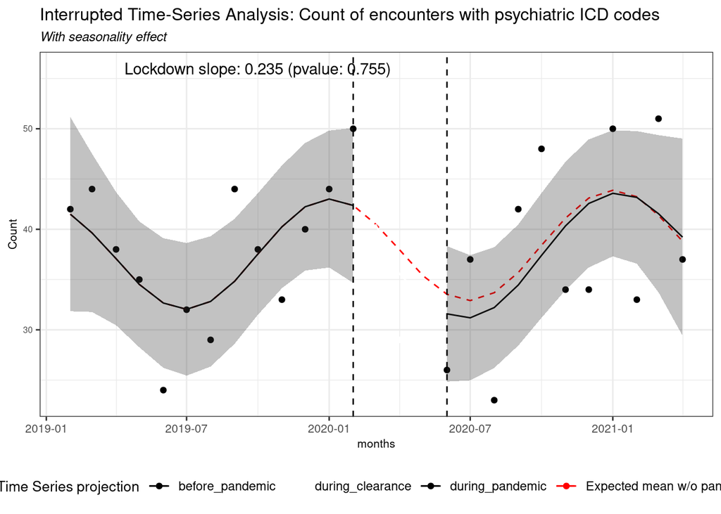

```r
time_series_analysis_plotting(ts_seasonal_count_clear,
                              patient_count_psy_period_psy,
                              "count_psy_patients",
                              clearance_period = TRUE) +
  labs(title = "Interrupted Time-Series Analysis: Count of encounters with psychiatric ICD codes",
       subtitle = "With seasonality effect",
       x = time_period,
       y = "Count")
```

### ITS: psy percentage, no clearance period, no seasonality effect

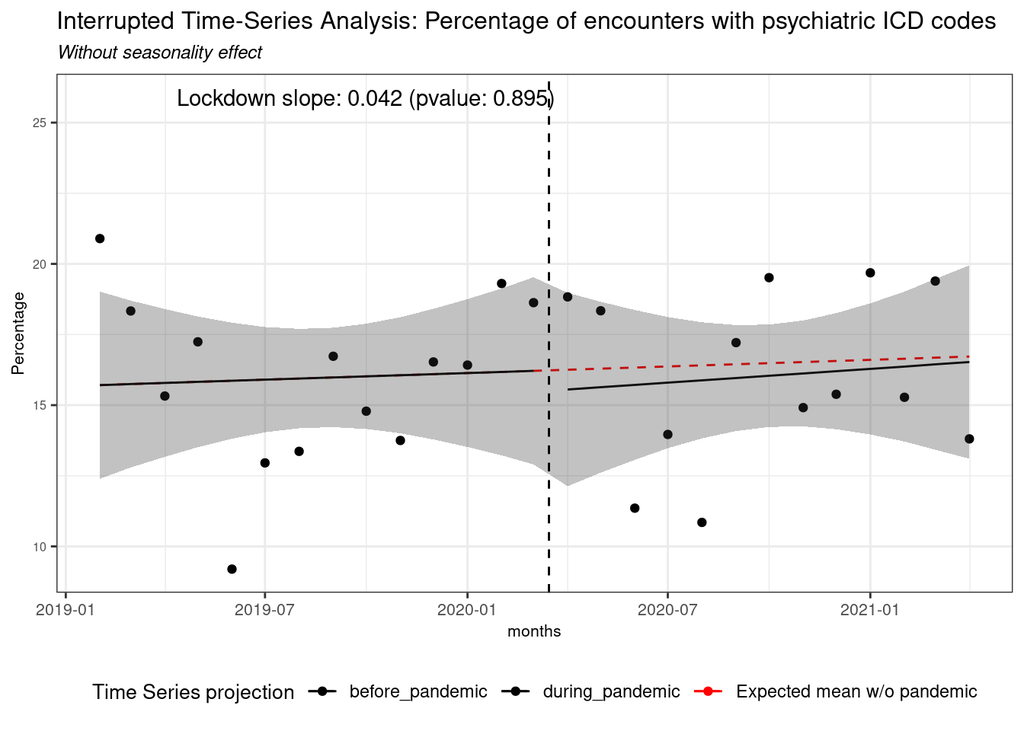

```r
time_series_analysis_plotting(ts_linear_percent,
                              patient_count_psy_period_psy,
                              "percentage",
                              clearance_period = FALSE) +
  labs(title = "Interrupted Time-Series Analysis: Percentage of encounters with psychiatric ICD codes",
       subtitle = "Without seasonality effect",
       x = time_period,
       y = "Percentage")
```

### ITS: psy percentage, clearance period, no seasonality effect

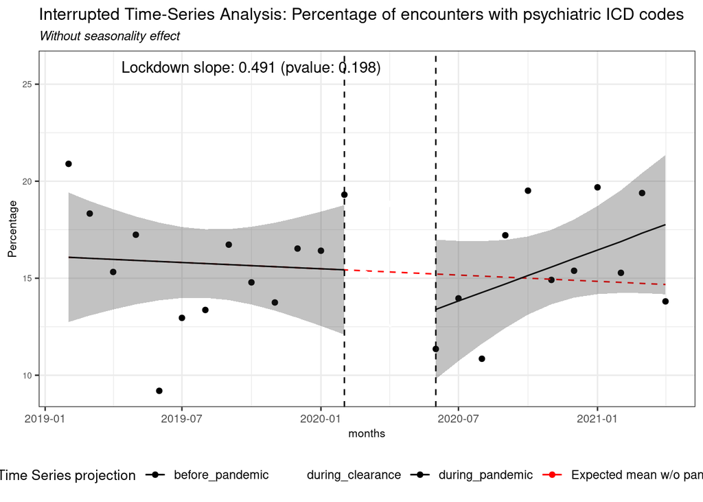

```r
time_series_analysis_plotting(ts_linear_percent_clear,
                              patient_count_psy_period_psy,
                              "percentage",
                              clearance_period = TRUE) +
  labs(title = "Interrupted Time-Series Analysis: Percentage of encounters with psychiatric ICD codes",
       subtitle = "Without seasonality effect",
       x = time_period,
       y = "Percentage")
```

### ITS: psy percentage, no clearance period, with seasonality effect

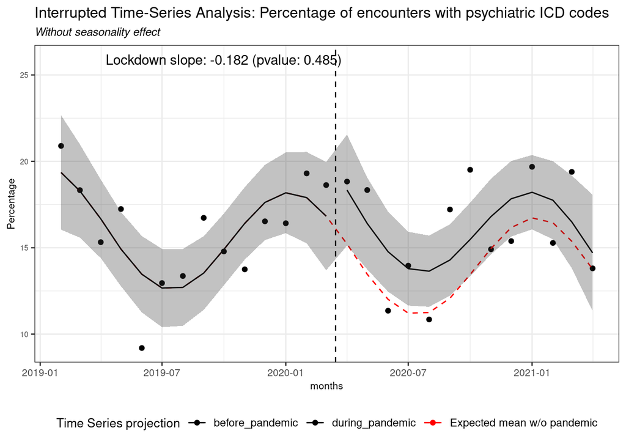

```r
time_series_analysis_plotting(ts_seasonal_percent,
                              patient_count_psy_period_psy,
                              "percentage",
                              clearance_period = FALSE) +
  labs(title = "Interrupted Time-Series Analysis: Percentage of encounters with psychiatric ICD codes",
       subtitle = "Without seasonality effect",
       x = time_period,
       y = "Percentage")
```

### ITS: psy percentage, with clearance period, with seasonality effect

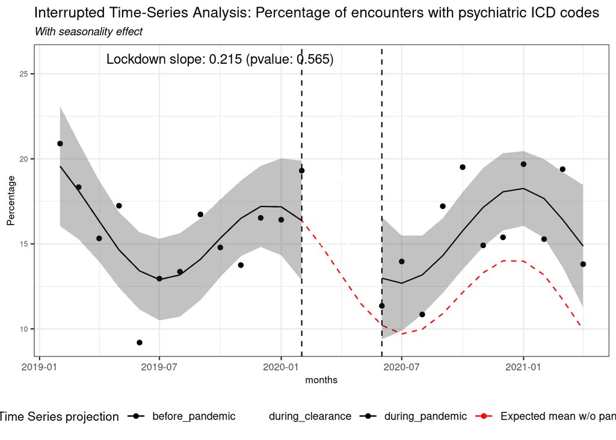

```r
time_series_analysis_plotting(ts_seasonal_percent_clear,
                              patient_count_psy_period_psy,
                              "percentage",
                              clearance_period = TRUE) +
  labs(title = "Interrupted Time-Series Analysis: Percentage of encounters with psychiatric ICD codes",
       subtitle = "With seasonality effect",
       x = time_period,
       y = "Percentage")
```

### ITS bootstrap

#### Parametric bootstrap

```r
bootstrap_size <- 1000
binom_proportion <- function(n, prob, size) {
  (rbinom(n, size, prob) / size) * 100
}
bootstrapped_timepoints <- mapply(binom_proportion,
                                  n = bootstrap_size,
                                  size = patient_count_psy_period_psy$count_no_psy_patients +
                                    patient_count_psy_period_psy$count_psy_patients,
                                  prob = patient_count_psy_period_psy$percentage/100)

bootstrapped_sample_list <- vector(mode = "list", length = bootstrap_size)
bootstrapped_coefficients_list <- vector(mode = "list", length = bootstrap_size)
for (iteration in 1:bootstrap_size) {
  df_iteration <- data.frame(period = patient_count_psy_period_psy$period,
                             time = patient_count_psy_period_psy$time,
                             percentage = bootstrapped_timepoints[iteration, ])
  ts_linear_percent <- lm(percentage ~ period * time, df_iteration)
  linear_model <- broom::tidy(ts_linear_percent) %>%
    filter(term %in% c("time", "periodduring_pandemic:time"))
  coefficients <- linear_model$estimate
  names(coefficients) <- linear_model$term
  bootstrapped_coefficients_list[[iteration]] <- coefficients
  df_iteration$predicted <- predict(ts_linear_percent)
  df_iteration$time_p <- patient_count_psy_period_psy$time_p
  bootstrapped_sample_list[[iteration]] <- df_iteration
}

bootstrapped_fitted_df <- bind_rows(bootstrapped_sample_list, .id = "iteration")

quantile_bootstrapped_fitted <- bootstrapped_fitted_df %>%
  group_by(time_p, period) %>%
  summarise("2.5%" = quantile(predicted, 0.025),
            "50%" = quantile(predicted, 0.5),
            "97.5%" = quantile(predicted, 0.975)) %>%
  pivot_longer(cols = c("2.5%", "50%", "97.5%"),
               names_to = "quantiles")
bootstrapped_coefficients_df <- bind_rows(bootstrapped_coefficients_list, .id = "iteration")
mean(bootstrapped_coefficients_df$time)
```

```
## [1] 0.03558746
```

```r
mean(bootstrapped_coefficients_df$time + bootstrapped_coefficients_df[["periodduring_pandemic:time"]])
```

```
## [1] 0.0787353
```

```r
pvalue_coeff_interaction <- round(t.test(bootstrapped_coefficients_df[["periodduring_pandemic:time"]])$p.value, 4)
# pvalue_coeff_interaction <- ifelse(pvalue_coeff_interaction == 0,
#                                    "< 1e-4",
#                                    str(pvalue_coeff_interaction))
if (pvalue_coeff_interaction == 0) {
  pvalue_coeff_interaction <- 1e-4
  print("equals 0")
} else {
  pvalue_coeff_interaction <- as.character(pvalue_coeff_interaction)
}
```

```
## [1] "equals 0"
```

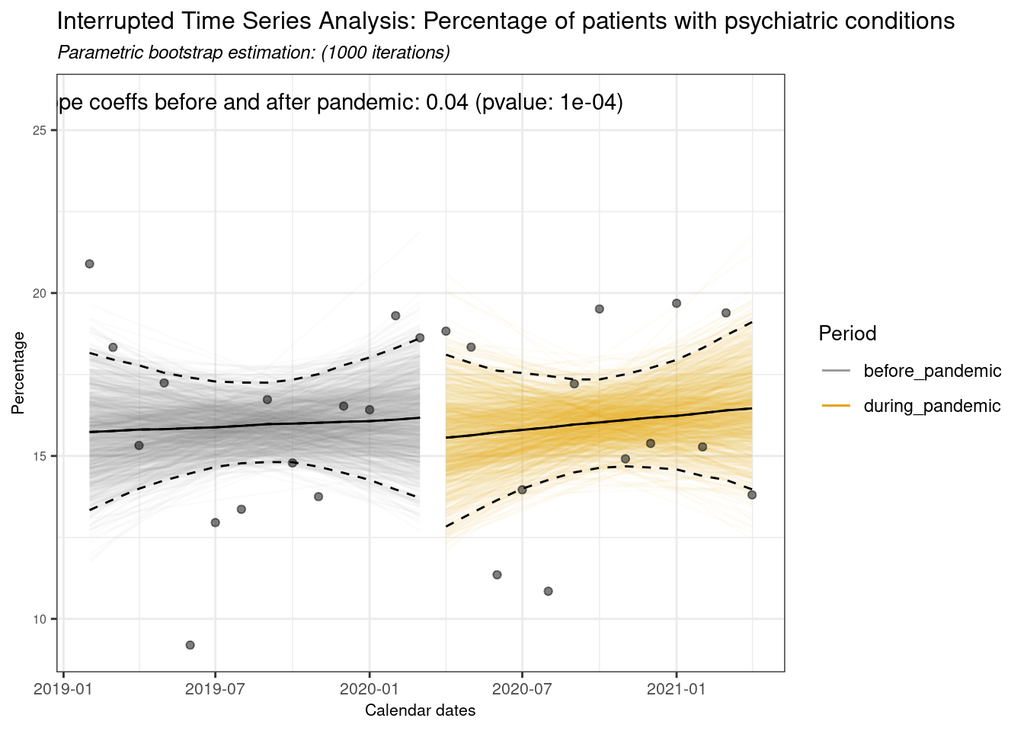

```r
plot_annotation <- paste0("Diff. in slope coeffs before and after pandemic: ",
                     round(mean(bootstrapped_coefficients_df[["periodduring_pandemic:time"]]), 2),
                     " (pvalue: ",
                     pvalue_coeff_interaction,
                     ")")

ggplot(bootstrapped_fitted_df, aes(x = time_p, y = predicted, group = interaction(iteration, period))) +
  geom_line(aes(color = period),
            alpha = 0.03) +
  geom_line(data = quantile_bootstrapped_fitted,
            aes(y = value, group = interaction(quantiles, period)),
            linetype = "dashed") +
  geom_line(data = quantile_bootstrapped_fitted[quantile_bootstrapped_fitted$quantiles == "50%", ],
            aes(y = value, group = period)) +
  geom_point(data = patient_count_psy_period_psy,
             aes(y = percentage),
             alpha = 0.5) +
  scale_colour_manual(values = cbPalette) +
  guides(color = guide_legend(override.aes = list(alpha = 1))) +
  annotate("text",
           x = as.Date("2019-10-01"),
           y = max(patient_count_psy_period_psy[["percentage"]]) + 5,
           label = plot_annotation) +
  labs(title = "Interrupted Time Series Analysis: Percentage of patients with psychiatric conditions",
       subtitle = "Parametric bootstrap estimation: (1000 iterations)",
       x = "Calendar dates",
       y = "Percentage",
       color = "Period")
```

## Psychiatric conditions aggregating by subcategories

### New admissions: count

```r
nrow(unique(data.frame(all_codes_psy$patient_num)))
```

```
## [1] 933
```

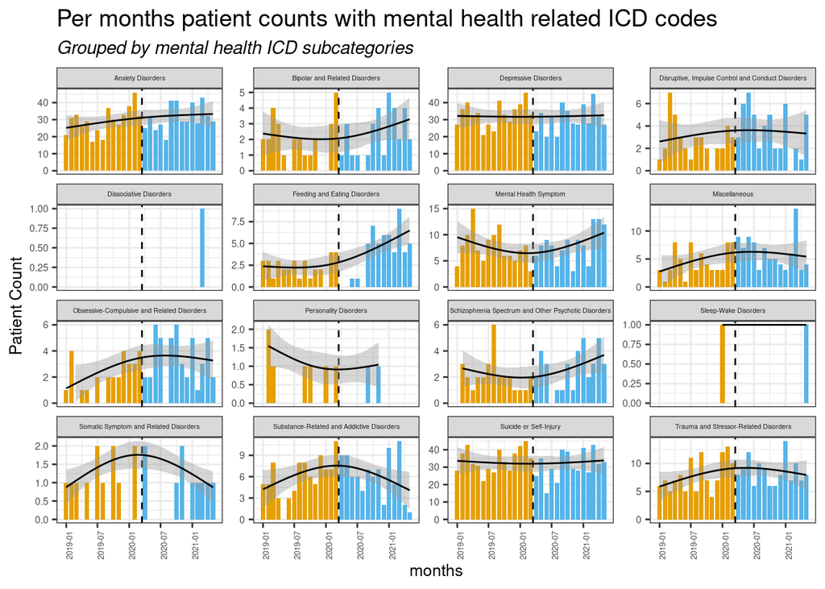

```r
count_disorder_group <- all_codes_psy %>%
  filter(date < end_date_plots &
         date >= start_date_plots ) %>%
    group_by( time_p, disorder_group ) %>%
  summarise(count_dg =  ifelse(n_distinct(patient_num) > obfuscation | isFALSE(obfuscation),
                               n_distinct(patient_num),
                               0.5)) %>%
  mutate( period = ifelse( time_p < pandemic_start_date,
                           "before_pandemic",
                           "during_pandemic")
  )
dg <- count_disorder_group %>%
  ggplot(aes(x = time_p, y= count_dg, fill = period, group = disorder_group )) +
  geom_bar(stat = "identity")+
  geom_vline(xintercept = as.Date(pandemic_start_date),
             linetype = "dashed") +
  geom_smooth(method = "lm", formula = y ~ splines::ns(x, 2), se= TRUE, aes(colour=period), colour= "black", size = 0.5) +
  labs(x = time_period,
       y = "Patient Count",
       title = paste0("Per ", time_period, " patient counts with mental health related ICD codes"),
       subtitle = "Grouped by mental health ICD subcategories") +
  ylim(0, NA) +
  facet_wrap(. ~ disorder_group, scales = "free_y") +
  theme(strip.text.x = element_text(size = 4),
        axis.text.x = element_text(size = 5, angle = 90),
        axis.text.y = element_text(size = 6),
        axis.title.x = element_text(size = 10),
        axis.title.y = element_text(size = 10),
        title = element_text(size = 12),
        plot.subtitle = element_text(size = 11),
        legend.position = "none") +
  scale_fill_manual(values = cbPalette[-1])

dg
```

#### Subset: the most prevalent disorder group

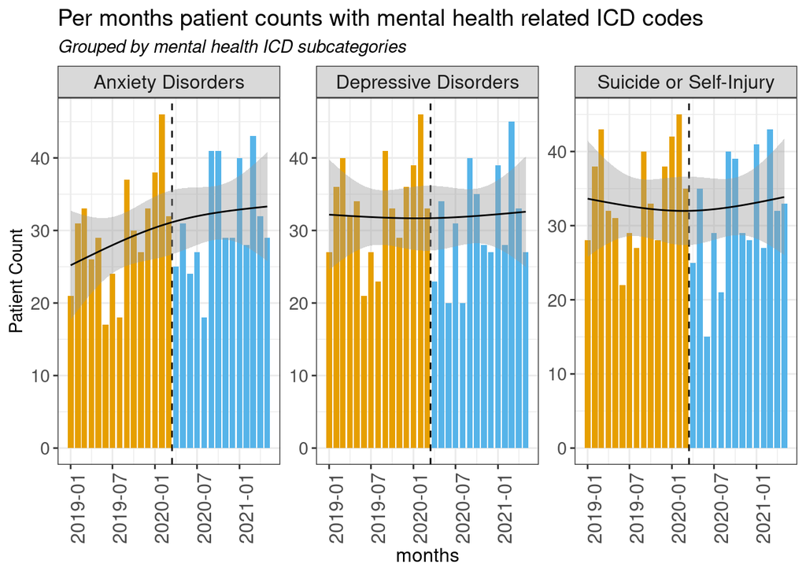

```r
dg_subset <- count_disorder_group %>%
  filter( disorder_group %in% c("Anxiety Disorders", "Depressive Disorders", "Suicide or Self-Injury" )) %>%
  ggplot(aes(x = time_p, y= count_dg, fill = period, group = disorder_group )) +
  geom_bar(stat = "identity")+
  geom_vline(xintercept = as.Date(pandemic_start_date),
             linetype = "dashed") +
  geom_smooth(method = "lm", formula = y ~ splines::ns(x, 2), se= TRUE, aes(colour=period), colour= "black", size = 0.5) +
  labs(x = time_period,
       y = "Patient Count",
       title = paste0("Per ", time_period, " patient counts with mental health related ICD codes"),
       subtitle = "Grouped by mental health ICD subcategories") +
  ylim(0, NA) +
  facet_wrap(. ~ disorder_group, scales = "free_y") +
  theme(strip.text.x = element_text(size = 12),
        axis.text.x = element_text(size = 12, angle = 90),
        axis.text.y = element_text(size = 11),
        axis.title.x = element_text(size = 12),
        axis.title.y = element_text(size = 11),
        title = element_text(size = 12),
        plot.subtitle = element_text(size = 11),
        legend.position = "none") +
  scale_fill_manual(values = cbPalette[-1])

dg_subset
```

### New admissions: percentage

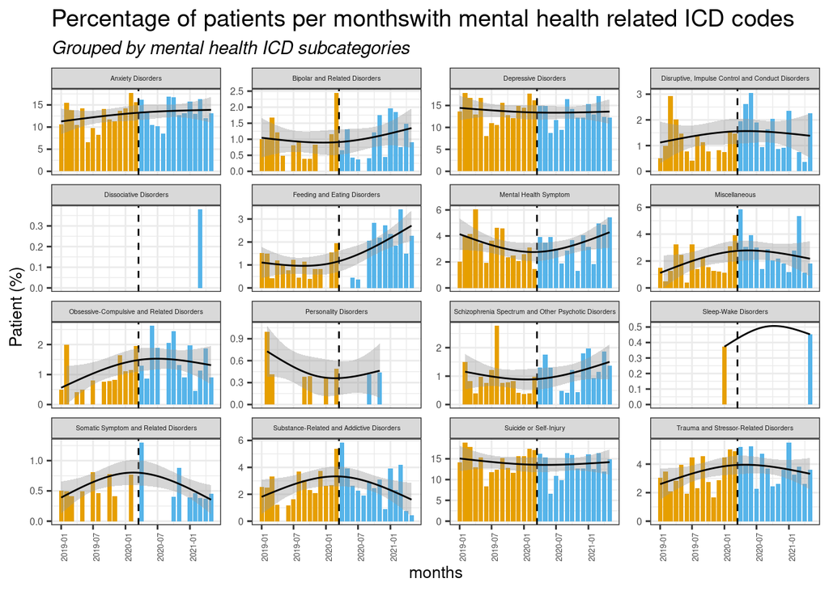

```r
# estimate the counts
count_icd_all <- all_codes_desc %>%
  filter(date < end_date_plots &
         date >= start_date_plots ) %>%
    group_by( time_p ) %>%
  summarise(count_icd =  ifelse(n_distinct(patient_num) > obfuscation | isFALSE(obfuscation),
                               n_distinct(patient_num),
                               0.5)) %>%
  mutate( period = ifelse( time_p < pandemic_start_date,
                           "before_pandemic",
                           "during_pandemic")
  )


# join the total with the disorder group count to estimate the percentage
perc_disorder_group <- count_icd_all %>%
  left_join(count_disorder_group,
            by = c("time_p", "period")) %>%
  replace_na(list(count_dg = 0))

perc_disorder_group$percentage_dg <- 100*perc_disorder_group$count_dg / perc_disorder_group$count_icd

dgPerc <- perc_disorder_group %>%
  ggplot(aes(x = time_p, y= percentage_dg, fill = period, group = disorder_group )) +
  geom_bar(stat = "identity")+
  geom_vline(xintercept = as.Date(pandemic_start_date),
             linetype = "dashed") +
  geom_smooth(method = "lm", formula = y ~ splines::ns(x, 2), se= TRUE, aes(colour=period), colour= "black", size = 0.5) +
  labs(x = time_period,
       y = "Patient (%)",
       title = paste0("Percentage of patients per ", time_period,"with mental health related ICD codes"),
       subtitle = "Grouped by mental health ICD subcategories") +
  ylim(0, NA) +
  facet_wrap(. ~ disorder_group, scales = "free_y") +
  theme(strip.text.x = element_text(size = 4),
        axis.text.x = element_text(size = 5, angle = 90),
        axis.text.y = element_text(size = 6),
        axis.title.x = element_text(size = 10),
        axis.title.y = element_text(size = 10),
        title = element_text(size = 12),
        plot.subtitle = element_text(size = 11),
        legend.position = "none") +
  scale_fill_manual(values = cbPalette[-1])

dgPerc
```

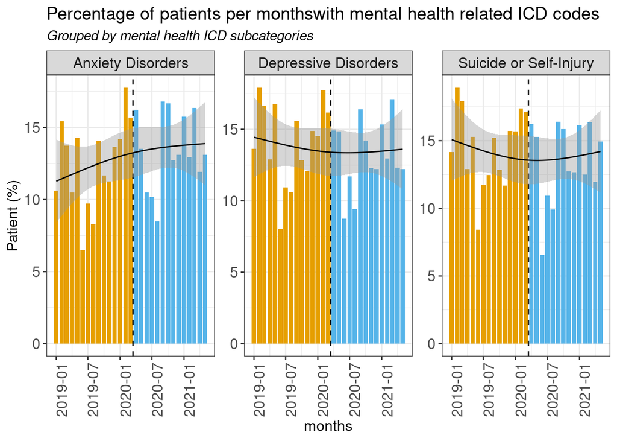

```r
dgPerc_subset <- perc_disorder_group %>%
  filter( disorder_group %in% c("Anxiety Disorders", "Depressive Disorders", "Suicide or Self-Injury" )) %>%
  ggplot(aes(x = time_p, y= percentage_dg, fill = period, group = disorder_group )) +
  geom_bar(stat = "identity")+
  geom_vline(xintercept = as.Date(pandemic_start_date),
             linetype = "dashed") +
  geom_smooth(method = "lm", formula = y ~ splines::ns(x, 2), se= TRUE, aes(colour=period), colour= "black", size = 0.5) +
  labs(x = time_period,
       y = "Patient (%)",
       title = paste0("Percentage of patients per ", time_period,"with mental health related ICD codes"),
       subtitle = "Grouped by mental health ICD subcategories") +
  ylim(0, NA) +
  facet_wrap(. ~ disorder_group, scales = "free_y") +
  theme(strip.text.x = element_text(size = 12),
        axis.text.x = element_text(size = 12, angle = 90),
        axis.text.y = element_text(size = 12),
        axis.title.x = element_text(size = 12),
        axis.title.y = element_text(size = 12),
        title = element_text(size = 12),
        plot.subtitle = element_text(size = 11),
        legend.position = "none") +
  scale_fill_manual(values = cbPalette[-1])

dgPerc_subset
```

## Psychiatric conditions, dichotomized on patients’ sex

### Count

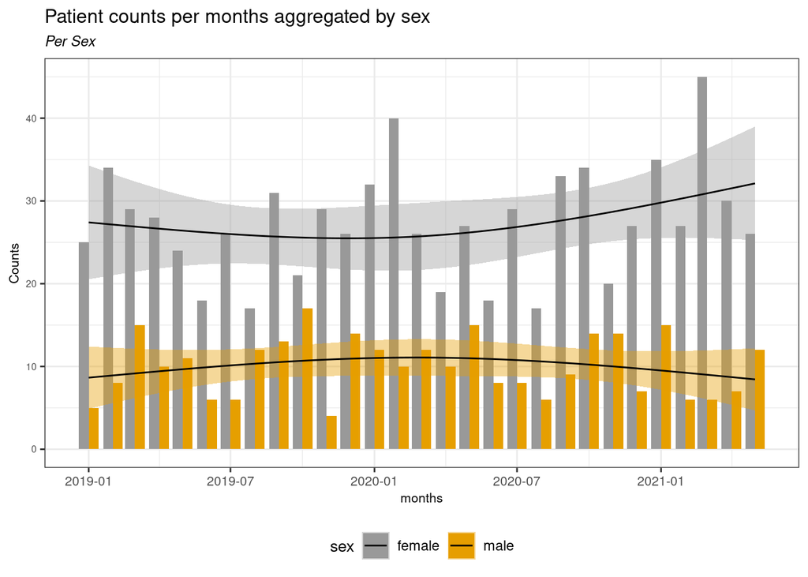

```r
# counts per time period and sex
patients_hospitalized_agg_sex <- all_codes_psy %>%
  filter(date < end_date_plots &
         date >= start_date_plots &
           sex %in% c("female", "male")) %>%
    group_by( time_p, sex ) %>%
  summarise(count_sex =  ifelse(n_distinct(patient_num) > obfuscation | isFALSE(obfuscation),
                               n_distinct(patient_num),
                               0.5))
patients_hospitalized_agg_sex %>%
  ggplot(aes(x = time_p, y = count_sex, fill = sex)) +
  geom_bar(stat="identity", position = "dodge")+
  scale_fill_manual(values = cbPalette) +
  labs(y = "Counts",
       x = time_period,
       title = paste0("Patient counts per ", time_period, " aggregated by sex"),
       subtitle = "Per Sex") +
  theme(legend.position = "bottom") +
  geom_smooth(method = "lm", formula = y ~ splines::ns(x, 2), se = TRUE, aes(colour=sex), colour= "black", size = 0.5)
```

### Percentage

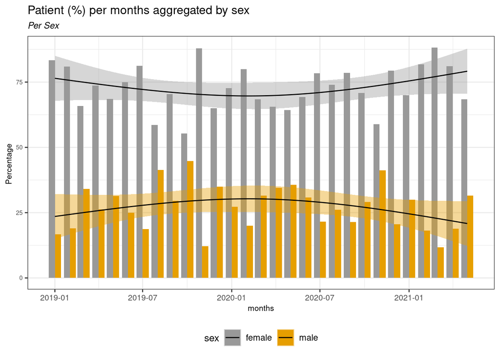

```r
##percentage
total_patients_psy <- all_codes_psy %>%
  filter(date < end_date_plots &
         date >= start_date_plots ) %>%
    group_by( time_p ) %>%
  summarise(count =  ifelse(n_distinct(patient_num) > obfuscation | isFALSE(obfuscation),
                               n_distinct(patient_num),
                               0.5))

patients_hospitalized_agg_sex_perc <- total_patients_psy %>%
  left_join( patients_hospitalized_agg_sex, by = c("time_p")) %>%
  replace_na(list(count_sex = 0))

patients_hospitalized_agg_sex_perc$percentage <- 100*patients_hospitalized_agg_sex_perc$count_sex/patients_hospitalized_agg_sex_perc$count

patients_hospitalized_agg_sex_perc %>%
  ggplot(aes(x = time_p, y = percentage, fill = sex)) +
  geom_bar(stat="identity", position = "dodge")+
  scale_fill_manual(values = cbPalette) +
  labs(y = "Percentage ",
       x = time_period,
       title = paste0("Patient (%) per ", time_period," aggregated by sex"),
       subtitle = "Per Sex") +
  theme(legend.position = "bottom") +
  geom_smooth(method = "lm", formula = y ~ splines::ns(x, 2), se = TRUE, aes(colour=sex), colour= "black", size = 0.5)
```

## Table 1

```r
t.test2 <- function(m1, m2, s1, s2, n1, n2) {
  # t.test computed from sample statistics, ie using mean, standard deviation and count value of the samples
  # useful in case we can only retrieve aggregated stats from the sites
  # ref: https://stats.stackexchange.com/questions/30394/how-to-perform-two-sample-t-tests-in-r-by-inputting-sample-statistics-rather-tha
  # and https://en.wikipedia.org/wiki/Student%27s_t-test?oldformat=true#Equal_or_unequal_sample_sizes,_unequal_variances_(sX1_%3E_2sX2_or_sX2_%3E_2sX1)
  se <- sqrt( (s1^2/n1) + (s2^2/n2) )
  # welch-satterthwaite df
  df <- ( (s1^2/n1 + s2^2/n2)^2 )/( (s1^2/n1)^2/(n1-1) + (s2^2/n2)^2/(n2-1) )
  t <- (m1-m2)/se
  dat <- c(m1-m2, se, t, 2*pt(-abs(t),df))
  names(dat) <- c("Difference of means", "Std Error", "t", "p-value")
  return(dat)
}

nrow(unique(data.frame(all_codes_psy$patient_num)))
```

```
## [1] 933
```

```r
age_by_period <- all_codes_psy %>%
  distinct(patient_num, age, period) %>%
  dplyr::group_by(period) %>%
  dplyr::summarise( mean = mean( age ),
                    sd = sd( age ),
                    count = n_distinct(patient_num))


age_test <- t.test2(m1 = age_by_period[[1, "mean"]],
                    m2 = age_by_period[[2, "mean"]],
                    s1 = age_by_period[[1, "sd"]],
                    s2 = age_by_period[[2, "sd"]],
                    n1 = age_by_period[[1, "count"]],
                    n2 = age_by_period[[2, "count"]]) %>%
  `[[`("p-value")
```

```r
sex <- all_codes_psy %>%
  dplyr::distinct(patient_num, sex) %>%
  dplyr::group_by( sex ) %>%
  dplyr::summarise( count = n_distinct(patient_num) ) %>%
  dplyr::mutate( count = ifelse( count > obfuscation, count, obfuscation * 0.5),
                 total = sum( count ), percentage = round( count/total*100, 2)  )

sex_by_period <- all_codes_psy %>%
  dplyr::distinct(patient_num, period, sex) %>%
  group_by(period, sex ) %>%
  summarise(count = n_distinct(patient_num)) %>%
  group_by(period, .add=TRUE) %>%
  mutate( count = ifelse( count > obfuscation, count, obfuscation * 0.5),
          percentage=round(count/sum( count )*100, 2)) %>%
  replace_na(list(male = 0, female = 0))
sex_test <- sex_by_period %>%
  select(-percentage) %>%
  pivot_wider(names_from = sex, values_from = count) %>%
  ungroup() %>%
  select(male, female) %>%
  chisq.test() %>%
  `[[`("p.value")
```

```r
summary_diagnosis <- all_codes_psy %>%
  dplyr::distinct( patient_num, description, period, weeks, concept_code ) %>%
  dplyr::group_by( concept_code, description, period ) %>%
  dplyr::count( patient_num ) %>%
  dplyr::tally(name = "count") %>%
  dplyr::mutate(count = ifelse( count > obfuscation, count, obfuscation * 0.5)) %>%
  dplyr::arrange( desc(count) ) %>%
  dplyr::ungroup()

summary_diagnosis_test <- summary_diagnosis %>%
  tidyr::pivot_wider(names_from = period,
                     values_from = count) %>%
  #select(late_pandemic, early_pandemic) %>%
  select(during_pandemic) %>%
  #tidyr::replace_na(list(late_pandemic = 0, early_pandemic = 0)) %>%
  tidyr::replace_na(list(during_pandemic = 0)) %>%
  chisq.test() %>%
  `[[`("p.value")
```

```r
summary_disorder_group <- all_codes_psy %>%
  dplyr::group_by( disorder_group ) %>%
  dplyr::count( patient_num ) %>%
  dplyr::tally(name = "count") %>%
  dplyr::mutate(count = ifelse( count > obfuscation, count, obfuscation * 0.5)) %>%
  dplyr::arrange( desc( count ))

summary_disorder_group_by_period <- all_codes_psy %>%
  dplyr::distinct( patient_num, disorder_group, period, weeks ) %>%
  dplyr::group_by( period, disorder_group ) %>%
  summarise(count = n_distinct(patient_num)) %>%
  group_by(period, .add=TRUE) %>%
  mutate(count = ifelse( count > obfuscation, count, obfuscation * 0.5),
         percentage = count/sum( count )*100)
summary_disorder_group_by_period_test <- summary_disorder_group_by_period %>%
  pivot_wider(id_cols = disorder_group, names_from = period, values_from = c(count, percentage)) %>%
  mutate(across(where(is.numeric), ~replace_na(.x, replace = 0))) %>%
  #select(count_early_pandemic, count_late_pandemic) %>%
  select(count_during_pandemic) %>%
  chisq.test() %>%
  `[[`("p.value")
```

```r
format_counts <- function(count, percentage) {
  glue::glue("{count} ({percentage} %)", count = count, percentage = percentage)
}


age_table1 <- age_by_period %>%
  mutate(result = glue::glue("{mean} (sd: {sd})", mean = round(mean, 2), sd = round(sd, 2))) %>%
  select(result, period) %>%
  pivot_wider( names_from = period, values_from = result ) %>%
  mutate(name = "Age")


sex_table1 <- sex_by_period %>%
  bind_rows(
    sex_by_period %>%
      group_by(period) %>%
      dplyr::summarise(sex = "Total", count = sum(count), percentage = sum(percentage))
  ) %>%
  mutate(result = format_counts(count, percentage)) %>%
  select(-c(count, percentage)) %>%
  pivot_wider( names_from = period, values_from = result ) %>%
  rename(name = sex)

disorder_table1 <- summary_disorder_group_by_period %>%
  arrange(desc(count)) %>%
  bind_rows(
    dplyr::summarise(., disorder_group="Total", across(where(is.numeric), sum))
  ) %>%
  mutate(percentage = round(percentage, 2)) %>%
  mutate(result = format_counts(count, percentage)) %>%
  select(-c(count, percentage)) %>%
  pivot_wider( names_from = period, values_from = result ) %>%
  replace_na( list(during_pandemic = "0 (0 %)")) %>%
  rename(name = disorder_group)
```

```r
list_tests <- c("Sex" = sex_test,
                "Age" = age_test,
                "Diagnoses" = summary_diagnosis_test,
                "Disorder groups" = summary_disorder_group_by_period_test
)

list_table1 <- list(
  "Sex" = sex_table1,
  "Age" = age_table1,
  "Disorder groups" = disorder_table1)


tests <- list_tests %>%
  data.frame() %>%
  round(2)
names(tests) <- "pvalue"
tests["Category"] <- row.names(tests)

table1 <- list_table1 %>%
  lapply(function(df) mutate(df, across(.fns = as.character))) %>%
  dplyr::bind_rows(.id = "Category") %>%
  dplyr::left_join(tests, by = "Category")


table1 %>%
  group_by(Category) %>%
  mutate(pvalue = ifelse(duplicated(pvalue, fromLast = TRUE), "", as.character(pvalue))) %>%
  ungroup() %>%
  mutate(Category = "") %>%
  mutate(across(.cols = c(before_pandemic, during_pandemic), .fns = replace_na, "0")) %>%
  rename_with(str_to_title) %>%
  rename_with(sub, pattern = "_", replacement = " ") %>%
  mutate(across(.fns = str_to_title)) %>%
  mutate(across(.fns = sub, pattern = "_", replacement = " ")) %>%
  kable( booktabs = T) %>%
  kableExtra::kable_styling(latex_options = "striped") %>%
  kableExtra::group_rows(index = setNames(rle(table1$Category)[[1]], rle(table1$Category)[[2]]))
```

| Category | Name | Before pandemic | During pandemic | Pvalue |
| --- | --- | --- | --- | --- |
| **Sex** |  |  |  |  |
|  | Female | 352 (71.69 %) | 350 (73.38 %) |  |
|  | Male | 139 (28.31 %) | 127 (26.62 %) |  |
|  | Total | 491 (100 %) | 477 (100 %) | 0.61 |
| **Age** |  |  |  |  |
|  | Age | 14.54 (Sd: 1.73) | 14.48 (Sd: 1.74) | 0.62 |
| **Disorder groups** |  |  |  |  |
|  | Suicide Or Self-Injury | 446 (25.14 %) | 407 (22.52 %) |  |
|  | Depressive Disorders | 438 (24.69 %) | 404 (22.36 %) |  |
|  | Anxiety Disorders | 383 (21.59 %) | 402 (22.25 %) |  |
|  | Trauma And Stressor-Related Disorders | 104 (5.86 %) | 112 (6.2 %) |  |
|  | Mental Health Symptom | 107 (6.03 %) | 105 (5.81 %) |  |
|  | Substance-Related And Addictive Disorders | 82 (4.62 %) | 88 (4.87 %) |  |
|  | Miscellaneous | 59 (3.33 %) | 74 (4.1 %) |  |
|  | Feeding And Eating Disorders | 32 (1.8 %) | 52 (2.88 %) |  |
|  | Obsessive-Compulsive And Related Disorders | 23 (1.3 %) | 45 (2.49 %) |  |
|  | Disruptive, Impulse Control And Conduct Disorders | 33 (1.86 %) | 42 (2.32 %) |  |
|  | Schizophrenia Spectrum And Other Psychotic Disorders | 27 (1.52 %) | 33 (1.83 %) |  |
|  | Bipolar And Related Disorders | 22 (1.24 %) | 28 (1.55 %) |  |
|  | Somatic Symptom And Related Disorders | 12 (0.68 %) | 10 (0.55 %) |  |
|  | Personality Disorders | 5 (0.28 %) | 3 (0.17 %) |  |
|  | Sleep-Wake Disorders | 1 (0.06 %) | 1 (0.06 %) |  |
|  | Dissociative Disorders | 0 | 1 (0.06 %) |  |
|  | Total | 1774 (100 %) | 1807 (100 %) | 0 |

# Save the output in a RData file.

```r
length_hospitalisation_values <- all_codes_psy %>%
  dplyr::distinct( patient_num, n_hospitalisation, len_hospitalisation, period ) %>%
  dplyr::mutate( siteid = site ) %>%
  dplyr::select( len_hospitalisation, siteid, period )

# add the site id as column for each of the output data frames
count_icd$siteid = site
patient_count_psy_period_psy$siteid = site
patient_count_psy_period_psy_clear$siteid = site
bootstrapped_coefficients_df$siteid = site
bootstrapped_fitted_df$siteid = site
perc_disorder_group$siteid = site
patients_hospitalized_agg_sex_perc$siteid = site
table1$siteid = site
ratios_patients_with_without_psy$siteid = site

save( count_icd,
      ratios_patients_with_without_psy,
      patient_count_psy_period_psy,
      patient_count_psy_period_psy_clear,
      bootstrapped_coefficients_df,
      bootstrapped_fitted_df,
      perc_disorder_group,
      patients_hospitalized_agg_sex_perc,
      table1,
      #length_hospitalisation_values,
      file = paste0("output/peds_psy_aggResults_", site, ".RData"))

rm(length_hospitalisation_values)
```